# SNAG Loop

## **Results**

### Behavior

#### Summary

Let’s double check for any sex differences in midlife adults here.

No sex differences for PE, or AE. Sex differences for degrees traveled with men undershooting and women overshooting.

#### Position Error

Males are normally distributed on PE

**Average**

| statistic | p.value | method |
| --- | --- | --- |
| 0.9618564 | 0.6378383 | Shapiro-Wilk normality test |

**rad3**

| statistic | p.value | method |
| --- | --- | --- |
| 0.9777442 | 0.9517613 | Shapiro-Wilk normality test |

[figure not shown]

**rad3**

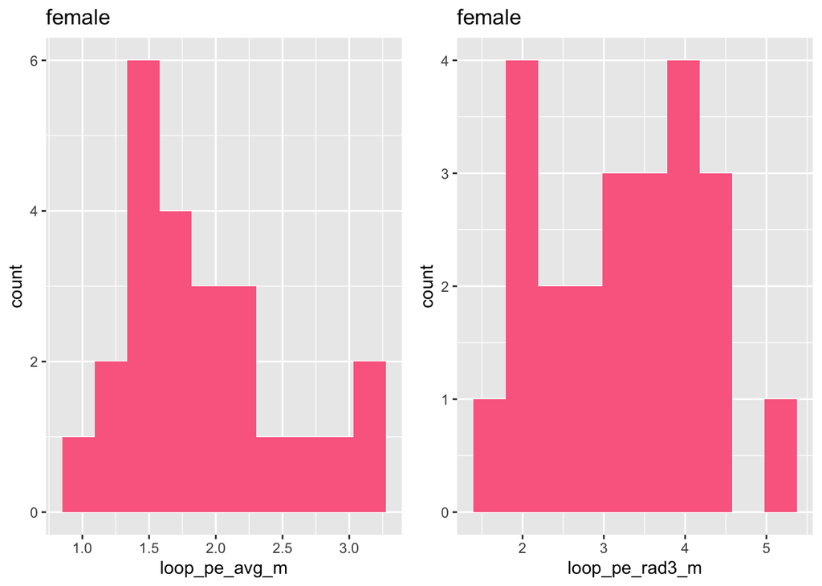

No sex differences for average position error

| estimate | estimate1 | estimate2 | statistic | p.value | parameter | conf.low | conf.high | method | alternative |
| --- | --- | --- | --- | --- | --- | --- | --- | --- | --- |
| -0.2640184 | 1.637906 | 1.901924 | -1.490887 | 0.1441085 | 38.64798 | -0.6223171 | 0.0942804 | Welch Two Sample t-test | two.sided |

No sex differences for rad3 position error

| estimate | estimate1 | estimate2 | statistic | p.value | parameter | conf.low | conf.high | method | alternative |
| --- | --- | --- | --- | --- | --- | --- | --- | --- | --- |
| -0.400442 | 2.832373 | 3.232815 | -1.378088 | 0.1770885 | 34.34626 | -0.9907484 | 0.1898644 | Welch Two Sample t-test | two.sided |

#### Angular Error

Both Avg and Rad3 are normally distributed

**Avg**

| statistic | p.value | method |
| --- | --- | --- |
| 0.9355756 | 0.2430819 | Shapiro-Wilk normality test |

**Rad3**

| statistic | p.value | method |
| --- | --- | --- |
| 0.9650577 | 0.7793542 | Shapiro-Wilk normality test |

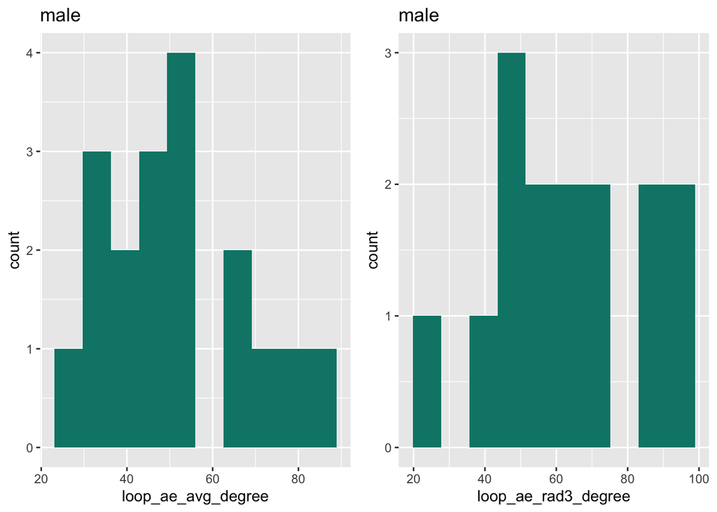

Average angular error for females is not normally distributed

| statistic | p.value | method |
| --- | --- | --- |
| 0.8818482 | 0.0090551 | Shapiro-Wilk normality test |

**rad3**

| statistic | p.value | method |
| --- | --- | --- |
| 0.937219 | 0.1565863 | Shapiro-Wilk normality test |

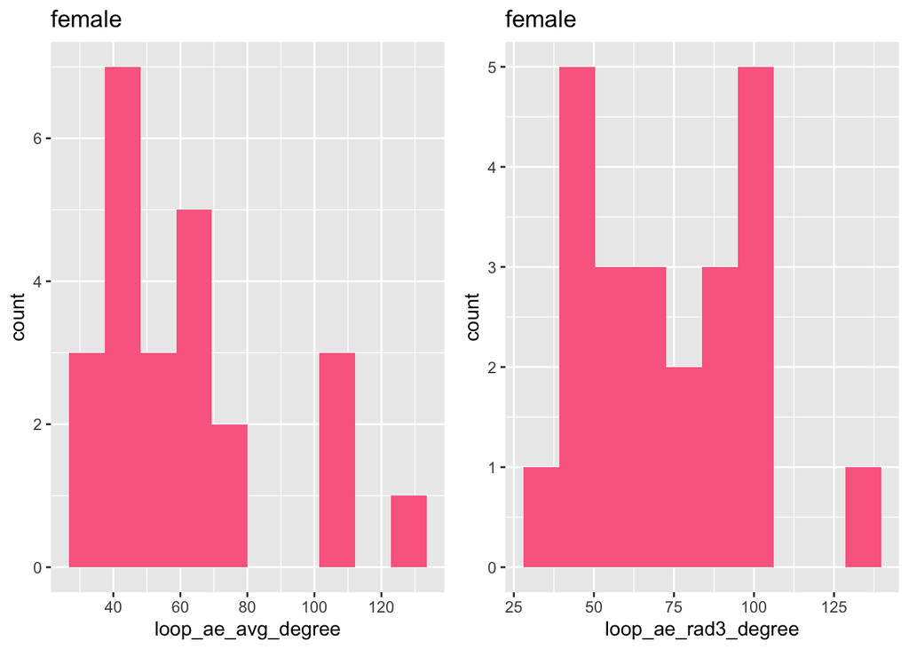

No sex differences for average position error. Used wilcox test since females are not normally distributed

| statistic | p.value | method | alternative |
| --- | --- | --- | --- |
| 177 | 0.3315378 | Wilcoxon rank sum exact test | two.sided |

No sex differences for rad3 position error

| estimate | estimate1 | estimate2 | statistic | p.value | parameter | conf.low | conf.high | method | alternative |
| --- | --- | --- | --- | --- | --- | --- | --- | --- | --- |
| -8.78427 | 63.7627 | 72.54697 | -1.114078 | 0.2729301 | 34.5779 | -24.79823 | 7.229692 | Welch Two Sample t-test | two.sided |

#### Degrees Traveled

**Avg**

| statistic | p.value | method |
| --- | --- | --- |
| 0.9204075 | 0.1314388 | Shapiro-Wilk normality test |

**Rad3**: Not normally distributed

| statistic | p.value | method |
| --- | --- | --- |
| 0.6672853 | 0.0001134 | Shapiro-Wilk normality test |

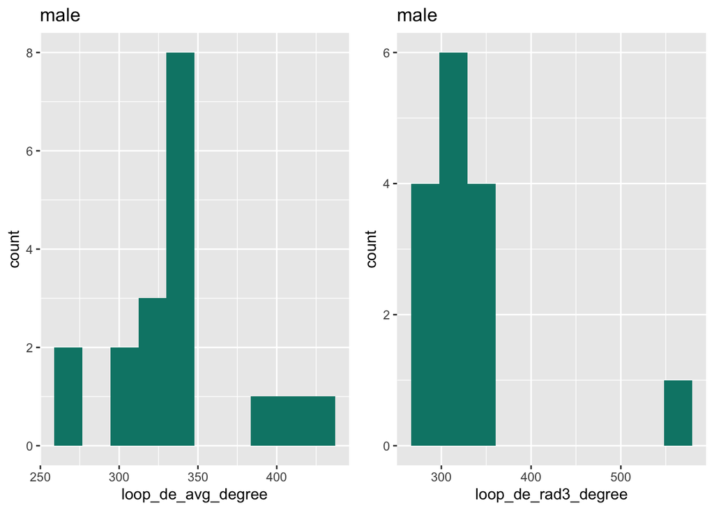

| statistic | p.value | method |
| --- | --- | --- |
| 0.9757515 | 0.806642 | Shapiro-Wilk normality test |

**rad3**

| statistic | p.value | method |
| --- | --- | --- |
| 0.9823592 | 0.9421131 | Shapiro-Wilk normality test |

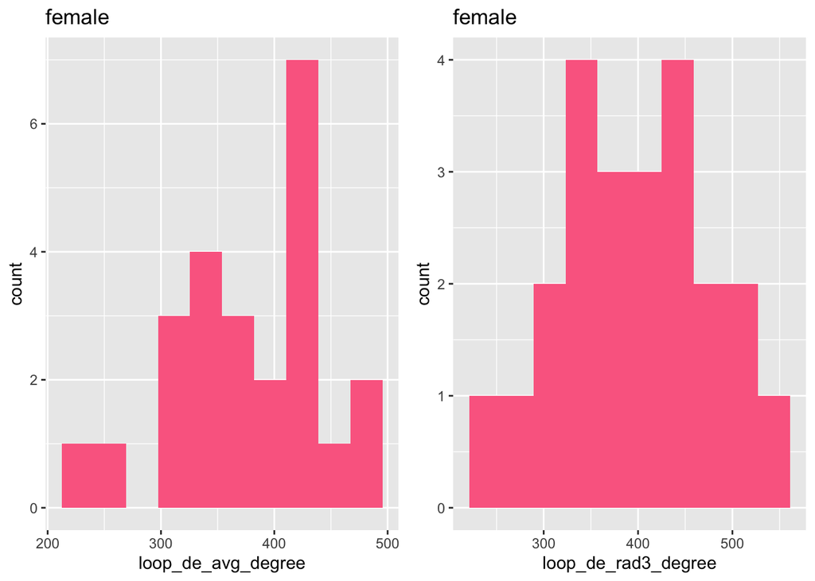

| estimate | estimate1 | estimate2 | statistic | p.value | parameter | conf.low | conf.high | method | alternative |
| --- | --- | --- | --- | --- | --- | --- | --- | --- | --- |
| -39.7847 | 337.3377 | 377.1224 | -2.422443 | 0.0202042 | 38.67599 | -73.01301 | -6.556386 | Welch Two Sample t-test | two.sided |

Sex differences in rad3 degrees traveled. Males had an average of 315.0809922 degrees traveled compared to females 394.6784529

| statistic | p.value | method | alternative |
| --- | --- | --- | --- |
| 81 | 0.0055177 | Wilcoxon rank sum exact test | two.sided |

### **Position Error**

#### Rad3

##### Summary

**QA FDRs**  
All: **( - ) 0.000760**  
Female: **( - ) 0.029793** | **(+) 0.005420**  
Male: **( - ) 0.040864** | ( + ) 0.184615  
Pre : **( - ) 0.020932** | ( + ) 0.068586  
Peri: **( - ) 0.048013**  
Post: No Significant Tracts

**MD FDRs**  
All: ( - ) 0.111613  
Female: **( - ) 0.007040**  
Male: **( + ) 0.011441**  
Pre : **( - ) 0.046384**  
Peri: **( - ) 0.014336**  
Post: ( - ) 0.064846

##### QA

###### All subject

**Negative (FDR = 0.000760)**

| Tract Name | number of tracts | mean length(mm) | diameter(mm) | volume(mm^3) |
| --- | --- | --- | --- | --- |
| Corticospinal_Tract_R | 349 | 57.6619 | 8.86616 | 3560 |
| Medial_Lemniscus_R | 178 | 58.3483 | 7.75779 | 2758 |
| Medial_Lemniscus_L | 146 | 56.3288 | 6.88969 | 2100 |
| Corticospinal_Tract_L | 73 | 54.7123 | 6.65825 | 1905 |
| Corticopontine_Tract_Parietal_R | 45 | 56.4444 | 6.02265 | 1608 |
| Dentatorubrothalamic_Tract_R | 43 | 54.2791 | 4.91777 | 1031 |
| Arcuate_Fasciculus_R | 41 | 51.9024 | 4.19393 | 717 |
| Corpus_Callosum_Tapetum | 28 | 58 | 4.79876 | 1049 |
| Corticostriatal_Tract_Superior_R | 18 | 52.7778 | 3.80773 | 601 |
| Thalamic_Radiation_Posterior_R | 17 | 55.7647 | 3.3889 | 503 |
| Corticostriatal_Tract_Superior_L | 14 | 55.7143 | 3.69058 | 596 |
| Arcuate_Fasciculus_L | 11 | 54 | 2.89723 | 356 |

###### Females

**Positive (FDR = 0.005420)**

| Tract Name | number of tracts | mean length(mm) | diameter(mm) | volume(mm^3) |
| --- | --- | --- | --- | --- |
| Corpus_Callosum_Forceps_Minor | 136 | 56.1324 | 7.17723 | 2271 |
| Cerebellum_L | 92 | 55.1956 | 5.10328 | 1129 |

**Negative (FDR = 0.029793)**

| Tract Name | number of tracts | mean length(mm) | diameter(mm) | volume(mm^3) |
| --- | --- | --- | --- | --- |
| Corticospinal_Tract_R | 199 | 55.8895 | 8.75553 | 3365 |
| Medial_Lemniscus_R | 163 | 55.7791 | 6.70923 | 1972 |
| Corticospinal_Tract_L | 48 | 54.625 | 5.27547 | 1194 |
| Dentatorubrothalamic_Tract_R | 43 | 57.1163 | 4.91121 | 1082 |
| Medial_Lemniscus_L | 22 | 54.1818 | 3.56226 | 540 |
| Extreme_Capsule_L | 18 | 53.2222 | 3.15468 | 416 |
| Corticostriatal_Tract_Superior_R | 18 | 51.7778 | 4.00719 | 653 |
| Inferior_Fronto_Occipital_Fasciculus_L | 16 | 55.125 | 3.31925 | 477 |
| Cerebellum_L | 14 | 53.4286 | 3.39969 | 485 |
| Arcuate_Fasciculus_R | 13 | 51.3846 | 3.16786 | 405 |

###### Males

**Positive (FDR = 0.184615)**

| Tract Name | number of tracts | mean length(mm) | diameter(mm) | volume(mm^3) |
| --- | --- | --- | --- | --- |
| Cerebellum_L | 168 | 58.9643 | 6.65006 | 2048 |
| Vermis | 43 | 52.3256 | 5.04021 | 1044 |
| Cerebellum_R | 30 | 52.3333 | 4.1474 | 707 |

**Negative (FDR = 0.040864)**

| Tract Name | number of tracts | mean length(mm) | diameter(mm) | volume(mm^3) |
| --- | --- | --- | --- | --- |
| Cerebellum_L | 509 | 56.6405 | 12.3654 | 6802 |
| Arcuate_Fasciculus_L | 71 | 56.9014 | 5.40586 | 1306 |
| Corpus_Callosum_Forceps_Major | 69 | 57.4493 | 5.75809 | 1496 |
| Cerebellum_R | 47 | 54.9787 | 4.53486 | 888 |
| Medial_Lemniscus_L | 20 | 54.5 | 3.59759 | 554 |
| Corpus_Callosum_Tapetum | 12 | 54.1667 | 3.37645 | 485 |

###### pre

**Positive (FDR = 0.068586)**

| Tract Name | number of tracts | mean length(mm) | diameter(mm) | volume(mm^3) |
| --- | --- | --- | --- | --- |
| Corpus_Callosum_Tapetum | 417 | 56.5947 | 11.0221 | 5400 |
| Corpus_Callosum_Forceps_Major | 376 | 62.1064 | 11.4635 | 6410 |
| Corpus_Callosum_Body | 271 | 60.2878 | 8.9431 | 3787 |
| Corticospinal_Tract_L | 178 | 60.9101 | 7.31527 | 2560 |
| Cerebellum_L | 165 | 55.9273 | 7.63419 | 2560 |
| Fornix_L | 108 | 64.7593 | 5.62797 | 1611 |
| Corticostriatal_Tract_Posterior_L | 59 | 54.4746 | 5.15058 | 1135 |
| Fornix_R | 50 | 55.8 | 3.56825 | 558 |
| Corticospinal_Tract_R | 40 | 57.9 | 4.43637 | 895 |
| Thalamic_Radiation_Posterior_L | 35 | 54.6286 | 4.87818 | 1021 |
| Inferior_Longitudinal_Fasciculus_L | 29 | 65.5862 | 4.45643 | 1023 |
| Cerebellum_R | 28 | 55.2857 | 3.24774 | 458 |
| Corticopontine_Tract_Parietal_L | 20 | 59.1 | 3.82751 | 680 |
| Medial_Lemniscus_L | 20 | 55.2 | 4.27143 | 791 |
| Inferior_Fronto_Occipital_Fasciculus_L | 16 | 55.5 | 3.48367 | 529 |
| Corpus_Callosum_Forceps_Minor | 15 | 54.4 | 3.1502 | 424 |
| Dentatorubrothalamic_Tract_L | 13 | 55.6923 | 3.05413 | 408 |
| Corticobulbar_Tract_L | 11 | 55.6364 | 3.14061 | 431 |

**Negative (FDR = 0.020932)**

| Tract Name | number of tracts | mean length(mm) | diameter(mm) | volume(mm^3) |
| --- | --- | --- | --- | --- |
| Corticospinal_Tract_R | 537 | 59.2588 | 10.6319 | 5261 |
| Corticospinal_Tract_L | 488 | 61.377 | 11.7258 | 6628 |
| Arcuate_Fasciculus_L | 317 | 57.142 | 10.3149 | 4775 |
| Medial_Lemniscus_R | 251 | 58.247 | 8.83884 | 3574 |
| Inferior_Fronto_Occipital_Fasciculus_L | 218 | 56.5505 | 7.6995 | 2633 |
| Superior_Longitudinal_Fasciculus2_R | 186 | 56.9247 | 8.74489 | 3419 |
| Dentatorubrothalamic_Tract_R | 151 | 59.298 | 7.73577 | 2787 |
| Corpus_Callosum_Body | 140 | 55.0571 | 9.32362 | 3759 |
| Corticostriatal_Tract_Superior_L | 137 | 56.8175 | 8.56551 | 3274 |
| Cerebellum_L | 114 | 55.386 | 7.48024 | 2434 |
| Corticostriatal_Tract_Superior_R | 113 | 56.0885 | 7.31162 | 2355 |
| Arcuate_Fasciculus_R | 108 | 55.9259 | 8.33021 | 3048 |
| Dentatorubrothalamic_Tract_L | 108 | 61.2963 | 7.50002 | 2708 |
| Cingulum_Frontal_Parietal_L | 101 | 54.0396 | 4.97149 | 1049 |
| Medial_Lemniscus_L | 100 | 59.02 | 6.48594 | 1950 |
| Inferior_Fronto_Occipital_Fasciculus_R | 98 | 57.7347 | 6.71558 | 2045 |
| Middle_Cerebellar_Peduncle | 81 | 54.9383 | 6.58322 | 1870 |
| Corpus_Callosum_Tapetum | 70 | 59.6571 | 6.0992 | 1743 |
| Superior_Longitudinal_Fasciculus2_L | 66 | 56.0303 | 6.08421 | 1629 |
| Cerebellum_R | 65 | 54.0308 | 6.91814 | 2031 |
| Extreme_Capsule_L | 57 | 60.4211 | 5.86077 | 1630 |
| Extreme_Capsule_R | 50 | 56.76 | 5.65381 | 1425 |
| Corticostriatal_Tract_Posterior_R | 50 | 55.52 | 6.37114 | 1770 |
| Corticopontine_Tract_Parietal_R | 38 | 63.8421 | 5.68582 | 1621 |
| Vermis | 34 | 53.0588 | 4.48434 | 838 |
| Cingulum_Parolfactory_R | 33 | 55.1515 | 3.45479 | 517 |
| Inferior_Longitudinal_Fasciculus_R | 31 | 54.9677 | 4.56839 | 901 |
| Cingulum_Frontal_Parietal_R | 26 | 54.9231 | 3.9293 | 666 |
| Corpus_Callosum_Forceps_Minor | 25 | 53.28 | 4.36144 | 796 |
| Corticopontine_Tract_Parietal_L | 23 | 63.3913 | 4.27524 | 910 |
| Superior_Longitudinal_Fasciculus1_R | 22 | 54.2727 | 3.71093 | 587 |
| Thalamic_Radiation_Posterior_R | 22 | 57.7273 | 4.52417 | 928 |
| Superior_Longitudinal_Fasciculus3_R | 18 | 55.7778 | 3.94852 | 683 |
| Thalamic_Radiation_Superior_R | 14 | 52.2857 | 3.61282 | 536 |
| Frontal_Aslant_Tract_L | 13 | 59.3846 | 3.67234 | 629 |
| Uncinate_Fasciculus_R | 12 | 54.3333 | 2.96441 | 375 |
| Superior_Longitudinal_Fasciculus3_L | 11 | 51.6364 | 3.50422 | 498 |

###### Peri

**Negative (FDR = 0.048013)**

| Tract Name | number of tracts | mean length(mm) | diameter(mm) | volume(mm^3) |
| --- | --- | --- | --- | --- |
| Corpus_Callosum_Forceps_Major | 306 | 68.366 | 13.079 | 9185 |
| Cerebellum_R | 298 | 55.094 | 15.3857 | 10243 |
| Corpus_Callosum_Tapetum | 271 | 71.476 | 13.1653 | 9730 |
| Corpus_Callosum_Body | 248 | 65.1936 | 13.6598 | 9554 |
| Superior_Longitudinal_Fasciculus2_R | 194 | 65.1031 | 10.6137 | 5760 |
| Cerebellum_L | 187 | 56.4813 | 12.1076 | 6503 |
| Inferior_Fronto_Occipital_Fasciculus_R | 184 | 70.4457 | 9.7772 | 5289 |
| Corticospinal_Tract_R | 182 | 71.0989 | 9.47485 | 5013 |
| Middle_Cerebellar_Peduncle | 182 | 58.2747 | 11.087 | 5626 |
| Arcuate_Fasciculus_R | 172 | 66.9884 | 10.6416 | 5958 |
| Dentatorubrothalamic_Tract_R | 157 | 66.5987 | 10.9328 | 6252 |
| Corticostriatal_Tract_Posterior_R | 121 | 68.0826 | 8.82878 | 4168 |
| Dentatorubrothalamic_Tract_L | 116 | 62.2241 | 9.61818 | 4521 |
| Cingulum_Frontal_Parietal_R | 111 | 72.7568 | 7.57511 | 3279 |
| Corticospinal_Tract_L | 111 | 66.036 | 8.4005 | 3660 |
| Medial_Lemniscus_R | 110 | 66.6545 | 8.14972 | 3477 |
| Inferior_Fronto_Occipital_Fasciculus_L | 109 | 70.8991 | 8.29992 | 3836 |
| Arcuate_Fasciculus_L | 91 | 58.8352 | 9.57786 | 4239 |
| Inferior_Longitudinal_Fasciculus_R | 91 | 62.2198 | 9.02582 | 3981 |
| Inferior_Longitudinal_Fasciculus_L | 88 | 65.2045 | 8.49192 | 3693 |
| Corticostriatal_Tract_Posterior_L | 74 | 61.4054 | 7.27146 | 2550 |
| Corticopontine_Tract_Parietal_R | 69 | 68.2899 | 7.17221 | 2759 |
| Anterior_Commissure | 69 | 73.1594 | 7.60704 | 3325 |
| Corticostriatal_Tract_Superior_L | 66 | 57.8182 | 8.22629 | 3073 |
| Thalamic_Radiation_Posterior_R | 66 | 62.3333 | 7.07854 | 2453 |
| Corticopontine_Tract_Parietal_L | 63 | 64.0952 | 6.17419 | 1919 |
| Corpus_Callosum_Forceps_Minor | 63 | 58.9841 | 8.16179 | 3086 |
| Thalamic_Radiation_Anterior_R | 57 | 64.2105 | 6.6958 | 2261 |
| Superior_Longitudinal_Fasciculus3_R | 56 | 63.1071 | 6.74062 | 2252 |
| Medial_Lemniscus_L | 54 | 61.5556 | 6.70735 | 2175 |
| Reticular_Tract_R | 52 | 71.5385 | 7.38826 | 3067 |
| Cingulum_Parahippocampal_Parietal_R | 50 | 59.56 | 6.03549 | 1704 |
| Superior_Longitudinal_Fasciculus1_R | 49 | 70.8571 | 5.54645 | 1712 |
| Corticostriatal_Tract_Superior_R | 46 | 63.087 | 6.93647 | 2384 |
| Superior_Longitudinal_Fasciculus2_L | 43 | 61.7674 | 6.04717 | 1774 |
| Vermis | 40 | 59.05 | 6.13223 | 1744 |
| Middle_Longitudinal_Fasciculus_R | 34 | 65.6471 | 6.02399 | 1871 |
| Corticopontine_Tract_Frontal_R | 33 | 58.3636 | 5.97779 | 1638 |
| Cingulum_Parolfactory_R | 32 | 70.5 | 4.37948 | 1062 |
| Thalamic_Radiation_Superior_R | 29 | 58.5517 | 5.90592 | 1604 |
| Thalamic_Radiation_Anterior_L | 26 | 63.2308 | 5.11244 | 1298 |
| Superior_Longitudinal_Fasciculus3_L | 25 | 59.76 | 4.90452 | 1129 |
| Frontal_Aslant_Tract_L | 24 | 59.75 | 4.86568 | 1111 |
| Corticopontine_Tract_Occipital_R | 24 | 65.9167 | 4.30843 | 961 |
| Cingulum_Frontal_Parietal_L | 23 | 65.913 | 4.56541 | 1079 |
| Extreme_Capsule_R | 23 | 66 | 4.61705 | 1105 |
| Middle_Longitudinal_Fasciculus_L | 23 | 55.6522 | 4.59033 | 921 |
| Parietal_Aslant_Tract_L | 23 | 58.1739 | 5.0539 | 1167 |
| Thalamic_Radiation_Posterior_L | 21 | 59.8095 | 4.8523 | 1106 |
| Uncinate_Fasciculus_R | 19 | 59.6842 | 4.18501 | 821 |
| Reticular_Tract_L | 19 | 67.1579 | 4.74985 | 1190 |
| Thalamic_Radiation_Superior_L | 18 | 57.1111 | 4.6431 | 967 |
| Fornix_R | 18 | 64.6667 | 4.28833 | 934 |
| Extreme_Capsule_L | 17 | 55.1765 | 4.39219 | 836 |
| Frontal_Aslant_Tract_R | 17 | 56.2353 | 4.15908 | 764 |
| Cingulum_Frontal_Parahippocampal_R | 16 | 70 | 3.7835 | 787 |
| Inferior_Cerebellar_Peduncle_R | 15 | 57.7333 | 3.97095 | 715 |
| Parietal_Aslant_Tract_R | 12 | 59.3333 | 3.57326 | 595 |
| Cingulum_Parahippocampal_Parietal_L | 11 | 62.9091 | 3.46146 | 592 |
| Optic_Radiation_L | 11 | 55.4545 | 3.45532 | 520 |
| Corticopontine_Tract_Frontal_L | 10 | 58.8 | 3.61647 | 604 |

###### post

No significant results

##### MD

###### All subject

**Negative (FDR = 0.111613)**

| Tract Name | number of tracts | mean length(mm) | diameter(mm) | volume(mm^3) |
| --- | --- | --- | --- | --- |
| Fornix_R | 929 | 56.4284 | 7.34046 | 2388 |
| Fornix_L | 554 | 54.8303 | 9.06792 | 3541 |
| Cingulum_Frontal_Parietal_L | 22 | 57.3636 | 3.68262 | 611 |
| Thalamic_Radiation_Superior_L | 21 | 53.5238 | 3.96236 | 660 |

###### Females

**Negative (FDR = 0.007040)**

| Tract Name | number of tracts | mean length(mm) | diameter(mm) | volume(mm^3) |
| --- | --- | --- | --- | --- |
| Fornix_L | 1315 | 56.8213 | 9.68499 | 4186 |
| Fornix_R | 642 | 56.5452 | 6.91405 | 2123 |
| Thalamic_Radiation_Superior_L | 45 | 54.4889 | 4.85324 | 1008 |
| Cingulum_Frontal_Parietal_L | 26 | 57.1538 | 3.58215 | 576 |
| Corpus_Callosum_Tapetum | 17 | 55.4118 | 3.35888 | 491 |

###### Males

**Positive (FDR = 0.011441)**

| Tract Name | number of tracts | mean length(mm) | diameter(mm) | volume(mm^3) |
| --- | --- | --- | --- | --- |
| Fornix_L | 1484 | 58.8571 | 9.6335 | 4290 |
| Fornix_R | 181 | 55.9669 | 6.30248 | 1746 |
| Thalamic_Radiation_Superior_L | 92 | 56.1304 | 5.58479 | 1375 |
| Corpus_Callosum_Forceps_Major | 41 | 54.6341 | 3.78583 | 615 |
| Cerebellum_L | 21 | 51.7143 | 2.64429 | 284 |

###### Pre

**Negative (FDR = 0.046384)**

| Tract Name | number of tracts | mean length(mm) | diameter(mm) | volume(mm^3) |
| --- | --- | --- | --- | --- |
| Fornix_L | 1767 | 60.6689 | 11.2681 | 6050 |
| Fornix_R | 873 | 59.0836 | 9.0778 | 3824 |
| Corpus_Callosum_Body | 220 | 60.4909 | 11.9672 | 6804 |
| Corpus_Callosum_Forceps_Major | 175 | 59.0629 | 7.87531 | 2877 |
| Cerebellum_R | 130 | 55.1846 | 6.33062 | 1737 |
| Thalamic_Radiation_Superior_L | 92 | 53.2826 | 6.00094 | 1507 |
| Optic_Radiation_L | 53 | 55.1698 | 5.3344 | 1233 |
| Corticostriatal_Tract_Posterior_R | 40 | 55.4 | 5.83218 | 1480 |
| Thalamic_Radiation_Superior_R | 37 | 54.5946 | 3.95587 | 671 |
| Thalamic_Radiation_Posterior_R | 27 | 54.3704 | 4.99869 | 1067 |
| Medial_Lemniscus_R | 19 | 58.8421 | 4.43987 | 911 |
| Arcuate_Fasciculus_R | 15 | 54.1333 | 3.91002 | 650 |
| Cingulum_Frontal_Parietal_L | 15 | 54.2667 | 3.26375 | 454 |
| Middle_Cerebellar_Peduncle | 12 | 52.1667 | 2.72393 | 304 |
| Inferior_Fronto_Occipital_Fasciculus_R | 11 | 56.5455 | 3.66643 | 597 |
| Inferior_Longitudinal_Fasciculus_R | 11 | 53.6364 | 3.55036 | 531 |
| Middle_Longitudinal_Fasciculus_R | 11 | 66.5454 | 3.39386 | 602 |
| Anterior_Commissure | 11 | 66.3636 | 2.43089 | 308 |

###### Peri

**Negative (FDR = 0.014336)**

| Tract Name | number of tracts | mean length(mm) | diameter(mm) | volume(mm^3) |
| --- | --- | --- | --- | --- |
| Corpus_Callosum_Tapetum | 127 | 64.2992 | 8.8597 | 3964 |
| Corpus_Callosum_Body | 107 | 57.8318 | 9.43344 | 4042 |
| Cerebellum_R | 98 | 55.2041 | 8.62451 | 3225 |
| Corpus_Callosum_Forceps_Major | 84 | 62.8571 | 8.56785 | 3624 |
| Corticostriatal_Tract_Posterior_R | 68 | 56.8529 | 7.44202 | 2473 |
| Inferior_Longitudinal_Fasciculus_R | 63 | 60.4762 | 7.27955 | 2517 |
| Fornix_L | 59 | 61.1525 | 5.96337 | 1708 |
| Cerebellum_L | 42 | 55.619 | 5.19077 | 1177 |
| Arcuate_Fasciculus_R | 29 | 58.6207 | 4.81406 | 1067 |
| Fornix_R | 26 | 57.3077 | 3.67536 | 608 |
| Arcuate_Fasciculus_L | 23 | 57.7391 | 4.45493 | 900 |
| Inferior_Fronto_Occipital_Fasciculus_L | 20 | 59.5 | 4.45146 | 926 |
| Inferior_Fronto_Occipital_Fasciculus_R | 18 | 59.8889 | 4.39364 | 908 |
| Corpus_Callosum_Forceps_Minor | 17 | 58.7059 | 4.23769 | 828 |
| Corticostriatal_Tract_Posterior_L | 16 | 59.875 | 4.28885 | 865 |
| Inferior_Longitudinal_Fasciculus_L | 15 | 58 | 3.92284 | 701 |
| Uncinate_Fasciculus_R | 15 | 54.6667 | 3.36097 | 485 |
| Dentatorubrothalamic_Tract_R | 14 | 63.1429 | 3.33326 | 551 |
| Medial_Lemniscus_L | 14 | 54.7143 | 3.56125 | 545 |
| Cingulum_Frontal_Parietal_L | 13 | 59.8462 | 2.99635 | 422 |
| Superior_Longitudinal_Fasciculus2_R | 13 | 55.2308 | 3.85607 | 645 |
| Middle_Cerebellar_Peduncle | 13 | 60.3077 | 3.63543 | 626 |
| Superior_Longitudinal_Fasciculus2_L | 12 | 58.8333 | 3.68951 | 629 |
| Dentatorubrothalamic_Tract_L | 11 | 58.3636 | 2.84493 | 371 |
| Reticular_Tract_L | 11 | 66.7273 | 3.13478 | 515 |
| Thalamic_Radiation_Posterior_L | 10 | 59 | 3.42317 | 543 |

###### Post

**Negative (FDR = 0.064846)**

| Tract Name | number of tracts | mean length(mm) | diameter(mm) | volume(mm^3) |
| --- | --- | --- | --- | --- |
| Arcuate_Fasciculus_L | 186 | 63.3333 | 9.86929 | 4845 |
| Corpus_Callosum_Forceps_Major | 152 | 59.6316 | 8.74418 | 3581 |
| Cerebellum_R | 105 | 54.7238 | 9.11894 | 3574 |
| Inferior_Longitudinal_Fasciculus_R | 101 | 61.0693 | 9.20719 | 4066 |
| Inferior_Longitudinal_Fasciculus_L | 97 | 64.1237 | 8.16191 | 3355 |
| Fornix_L | 92 | 57.3696 | 5.87839 | 1557 |
| Corpus_Callosum_Tapetum | 88 | 61.9773 | 8.89227 | 3849 |
| Cerebellum_L | 77 | 53.3766 | 8.04163 | 2711 |
| Corpus_Callosum_Body | 76 | 59.9211 | 8.64596 | 3518 |
| Superior_Longitudinal_Fasciculus2_L | 65 | 58.2462 | 7.14132 | 2333 |
| Corpus_Callosum_Forceps_Minor | 45 | 58.8 | 6.8564 | 2171 |
| Corticostriatal_Tract_Posterior_L | 44 | 61.9545 | 5.9177 | 1704 |
| Corticostriatal_Tract_Posterior_R | 29 | 57.3793 | 5.56969 | 1398 |
| Inferior_Fronto_Occipital_Fasciculus_L | 27 | 59.6296 | 5.28277 | 1307 |
| Inferior_Fronto_Occipital_Fasciculus_R | 26 | 59 | 5.32711 | 1315 |
| Frontal_Aslant_Tract_L | 25 | 66 | 4.29225 | 955 |
| Fornix_R | 24 | 55.6667 | 3.34093 | 488 |
| Medial_Lemniscus_R | 23 | 58.5217 | 4.68303 | 1008 |
| Thalamic_Radiation_Superior_L | 22 | 60.5455 | 3.82302 | 695 |
| Arcuate_Fasciculus_R | 18 | 57.2222 | 4.69106 | 989 |
| Thalamic_Radiation_Posterior_L | 18 | 53.6667 | 4.57961 | 884 |
| Dentatorubrothalamic_Tract_L | 18 | 56.4445 | 4.36072 | 843 |
| Superior_Longitudinal_Fasciculus2_R | 16 | 56.875 | 4.4005 | 865 |
| Corticostriatal_Tract_Anterior_R | 12 | 53.3333 | 3.82548 | 613 |
| Thalamic_Radiation_Anterior_L | 12 | 54.6667 | 4.01174 | 691 |
| Corticopontine_Tract_Parietal_R | 11 | 72.3636 | 3.15017 | 564 |
| Corticostriatal_Tract_Anterior_L | 11 | 54.5455 | 3.85608 | 637 |
| Extreme_Capsule_R | 10 | 54.6 | 3.57804 | 549 |
| Parietal_Aslant_Tract_L | 10 | 56.6 | 2.61937 | 305 |

#### Average

##### Summary

**QA FDRs**  
All: ( - ) 0.067564 | **( + ) 0.015957**  
Female: **( - ) 0.001030** | **( + ) 0.002551**  
Male: **( - ) 0.017570**  
Pre : **( - ) 0.037464** | ( + ) 0.163683  
Peri: **( - ) 0.034684**  
Post: ( - ) 0.145591

**MD FDRs**  
All: **( - ) 0.000150** Female: **( - ) 0.000147**  
Male: **( + ) 0.006360**  
Pre : **( - ) 0.032327**  
Peri: **( - ) 0.018830**  
Post: ( - ) 0.088732

##### QA

###### All subject

**Positive (FDR = 0.015957)**

| Tract Name | number of tracts | mean length(mm) | diameter(mm) | volume(mm^3) |
| --- | --- | --- | --- | --- |
| Corpus_Callosum_Forceps_Minor | 100 | 53.7 | 7.33959 | 2272 |
| Cingulum_Frontal_Parahippocampal_R | 22 | 53.1818 | 2.56123 | 274 |

**Negative (FDR = 0.067564)**

| Tract Name | number of tracts | mean length(mm) | diameter(mm) | volume(mm^3) |
| --- | --- | --- | --- | --- |
| Corticospinal_Tract_R | 1104 | 57.3623 | 11.3101 | 5763 |
| Corpus_Callosum_Forceps_Major | 241 | 55.3693 | 7.77084 | 2626 |
| Medial_Lemniscus_R | 228 | 57.2368 | 8.13916 | 2978 |
| Corticospinal_Tract_L | 198 | 54.6465 | 8.81103 | 3332 |
| Dentatorubrothalamic_Tract_R | 168 | 53.7143 | 7.0335 | 2087 |
| Medial_Lemniscus_L | 100 | 55.2 | 6.27483 | 1707 |
| Cerebellum_R | 78 | 53.9231 | 5.66887 | 1361 |
| Corpus_Callosum_Tapetum | 63 | 54.5397 | 6.03864 | 1562 |
| Corticostriatal_Tract_Superior_R | 59 | 53.4237 | 6.5661 | 1809 |
| Arcuate_Fasciculus_L | 29 | 55.5172 | 4.4126 | 849 |
| Corticostriatal_Tract_Superior_L | 23 | 54.087 | 4.48896 | 856 |
| Dentatorubrothalamic_Tract_L | 18 | 54.4444 | 4.1936 | 752 |
| Arcuate_Fasciculus_R | 17 | 51.2941 | 2.96012 | 353 |
| Superior_Longitudinal_Fasciculus2_L | 12 | 60.5 | 3.37112 | 540 |
| Corticopontine_Tract_Parietal_R | 10 | 60.2 | 3.33224 | 525 |

###### Females

**Positive (FDR = 0.002551)**

| Tract Name | number of tracts | mean length(mm) | diameter(mm) | volume(mm^3) |
| --- | --- | --- | --- | --- |
| Corpus_Callosum_Forceps_Minor | 173 | 53.2023 | 7.32173 | 2240 |
| Cerebellum_L | 58 | 55.6207 | 4.49336 | 882 |
| Cingulum_Frontal_Parahippocampal_R | 10 | 50.8 | 2.17648 | 189 |

**Negative (FDR = 0.001030)**

| Tract Name | number of tracts | mean length(mm) | diameter(mm) | volume(mm^3) |
| --- | --- | --- | --- | --- |
| Corticospinal_Tract_R | 268 | 56.1343 | 9.51083 | 3988 |
| Medial_Lemniscus_R | 245 | 56.0571 | 7.33537 | 2369 |
| Dentatorubrothalamic_Tract_R | 74 | 55.4865 | 6.18485 | 1667 |
| Corticostriatal_Tract_Superior_R | 37 | 52.7568 | 4.60586 | 879 |
| Inferior_Fronto_Occipital_Fasciculus_L | 36 | 56.6667 | 4.4643 | 887 |
| Corticospinal_Tract_L | 30 | 57.3333 | 4.38035 | 864 |
| Corpus_Callosum_Forceps_Major | 15 | 53.4667 | 2.82024 | 334 |
| Extreme_Capsule_L | 13 | 56.6154 | 2.73248 | 332 |

###### Males

**Negative (FDR = 0.017570)**

| Tract Name | number of tracts | mean length(mm) | diameter(mm) | volume(mm^3) |
| --- | --- | --- | --- | --- |
| Cerebellum_L | 2824 | 56.8045 | 20.4589 | 18674 |
| Cerebellum_R | 271 | 54.6494 | 9.45492 | 3837 |
| Middle_Cerebellar_Peduncle | 124 | 56.4355 | 7.81489 | 2707 |
| Corpus_Callosum_Forceps_Major | 98 | 58.8367 | 6.89361 | 2196 |
| Vermis | 88 | 56.1364 | 6.46365 | 1842 |
| Fornix_L | 70 | 53.9714 | 5.17681 | 1136 |
| Cingulum_Frontal_Parietal_L | 23 | 55.0435 | 2.79615 | 338 |
| Corticospinal_Tract_R | 17 | 54.2353 | 3.10624 | 411 |
| Dentatorubrothalamic_Tract_R | 16 | 52.375 | 3.15322 | 409 |
| Corpus_Callosum_Tapetum | 10 | 57 | 2.78007 | 346 |

###### Pre

**Positive (FDR = 0.163683)**

| Tract Name | number of tracts | mean length(mm) | diameter(mm) | volume(mm^3) |
| --- | --- | --- | --- | --- |
| Corpus_Callosum_Tapetum | 185 | 54.0541 | 8.65747 | 3182 |
| Corpus_Callosum_Forceps_Major | 177 | 60.339 | 9.04957 | 3881 |
| Cerebellum_L | 118 | 55.4068 | 6.74708 | 1981 |
| Corpus_Callosum_Body | 83 | 59.3012 | 6.05219 | 1706 |
| Fornix_L | 40 | 57.3 | 3.23854 | 472 |
| Corticospinal_Tract_L | 28 | 57.2143 | 3.66624 | 604 |
| Fornix_R | 22 | 53.4545 | 2.89557 | 352 |
| Corpus_Callosum_Forceps_Minor | 17 | 56.4706 | 2.72359 | 329 |
| Thalamic_Radiation_Posterior_L | 11 | 54 | 3.19892 | 434 |

**Negative (FDR = 0.037464)**

| Tract Name | number of tracts | mean length(mm) | diameter(mm) | volume(mm^3) |
| --- | --- | --- | --- | --- |
| Corticospinal_Tract_R | 586 | 57.1945 | 10.1183 | 4599 |
| Corticospinal_Tract_L | 391 | 58.0051 | 10.7646 | 5279 |
| Medial_Lemniscus_R | 228 | 56.4035 | 8.35588 | 3093 |
| Inferior_Fronto_Occipital_Fasciculus_L | 189 | 55.4074 | 6.82661 | 2028 |
| Dentatorubrothalamic_Tract_R | 168 | 54.8095 | 6.9378 | 2072 |
| Corticostriatal_Tract_Superior_R | 163 | 55.4969 | 7.66823 | 2563 |
| Arcuate_Fasciculus_L | 148 | 55.6216 | 7.90957 | 2733 |
| Inferior_Fronto_Occipital_Fasciculus_R | 148 | 58.027 | 7.1915 | 2357 |
| Corticostriatal_Tract_Superior_L | 103 | 54.4078 | 7.82127 | 2614 |
| Cerebellum_L | 103 | 56.0777 | 6.37865 | 1792 |
| Cingulum_Frontal_Parietal_L | 99 | 54.1414 | 4.99279 | 1060 |
| Medial_Lemniscus_L | 99 | 57.0101 | 6.12539 | 1680 |
| Superior_Longitudinal_Fasciculus2_R | 87 | 54.6207 | 6.92963 | 2060 |
| Arcuate_Fasciculus_R | 81 | 56.2222 | 6.39883 | 1808 |
| Corpus_Callosum_Body | 69 | 54 | 7.02494 | 2093 |
| Dentatorubrothalamic_Tract_L | 67 | 57.8806 | 5.92708 | 1597 |
| Cingulum_Parolfactory_R | 55 | 58.0364 | 3.74124 | 638 |
| Superior_Longitudinal_Fasciculus1_R | 45 | 55.0222 | 4.33475 | 812 |
| Corpus_Callosum_Tapetum | 42 | 54.8571 | 4.8989 | 1034 |
| Superior_Longitudinal_Fasciculus2_L | 37 | 57.2973 | 4.3024 | 833 |
| Extreme_Capsule_R | 36 | 55.8889 | 4.70571 | 972 |
| Extreme_Capsule_L | 35 | 58.6286 | 4.75244 | 1040 |
| Cingulum_Frontal_Parietal_R | 31 | 54.7742 | 3.98161 | 682 |
| Corticopontine_Tract_Parietal_L | 28 | 62.2857 | 4.61967 | 1044 |
| Vermis | 26 | 52.5385 | 3.84802 | 611 |
| Cerebellum_R | 24 | 51.75 | 4.27557 | 743 |
| Corticopontine_Tract_Parietal_R | 21 | 58.6667 | 4.40728 | 895 |
| Inferior_Longitudinal_Fasciculus_R | 15 | 54.8 | 3.13127 | 422 |
| Corticostriatal_Tract_Posterior_R | 13 | 54.6154 | 3.42438 | 503 |
| Cingulum_Frontal_Parahippocampal_L | 12 | 52.5 | 2.92592 | 353 |
| Middle_Cerebellar_Peduncle | 10 | 51.2 | 2.11571 | 180 |

###### Peri

**Negative (FDR = 0.034684)**

| Tract Name | number of tracts | mean length(mm) | diameter(mm) | volume(mm^3) |
| --- | --- | --- | --- | --- |
| Corpus_Callosum_Forceps_Major | 316 | 67.7595 | 13.1931 | 9263 |
| Corpus_Callosum_Tapetum | 270 | 71.6963 | 13.0508 | 9591 |
| Cerebellum_R | 250 | 55.232 | 14.5346 | 9164 |
| Corpus_Callosum_Body | 225 | 66.72 | 12.7301 | 8492 |
| Superior_Longitudinal_Fasciculus2_R | 219 | 64.7306 | 10.9412 | 6086 |
| Inferior_Fronto_Occipital_Fasciculus_R | 218 | 69.8991 | 10.0101 | 5501 |
| Corticospinal_Tract_R | 196 | 72.5408 | 9.58292 | 5232 |
| Arcuate_Fasciculus_R | 187 | 66.2888 | 10.7083 | 5970 |
| Middle_Cerebellar_Peduncle | 181 | 58.8729 | 11.0736 | 5670 |
| Dentatorubrothalamic_Tract_R | 174 | 67.4483 | 11.3373 | 6809 |
| Cerebellum_L | 161 | 56.6584 | 11.8862 | 6287 |
| Corticostriatal_Tract_Posterior_R | 130 | 67.9231 | 8.98219 | 4304 |
| Medial_Lemniscus_R | 127 | 66.6142 | 8.40841 | 3699 |
| Cingulum_Frontal_Parietal_R | 120 | 72.7833 | 7.71787 | 3405 |
| Dentatorubrothalamic_Tract_L | 120 | 60.6667 | 9.58776 | 4380 |
| Inferior_Fronto_Occipital_Fasciculus_L | 113 | 70.7257 | 8.26012 | 3790 |
| Arcuate_Fasciculus_L | 111 | 59.0991 | 9.59918 | 4277 |
| Corticospinal_Tract_L | 99 | 64.7273 | 8.12377 | 3355 |
| Inferior_Longitudinal_Fasciculus_R | 94 | 61.8723 | 9.08064 | 4007 |
| Inferior_Longitudinal_Fasciculus_L | 92 | 64.8696 | 8.54947 | 3724 |
| Corticopontine_Tract_Parietal_R | 75 | 68.6933 | 7.35932 | 2922 |
| Anterior_Commissure | 75 | 71.2533 | 7.95005 | 3537 |
| Corticostriatal_Tract_Posterior_L | 73 | 62.3562 | 7.36981 | 2660 |
| Thalamic_Radiation_Anterior_R | 71 | 65.662 | 6.96533 | 2502 |
| Thalamic_Radiation_Posterior_R | 71 | 62.0563 | 6.98502 | 2378 |
| Corticopontine_Tract_Parietal_L | 67 | 64.597 | 6.20122 | 1951 |
| Reticular_Tract_R | 66 | 75.1515 | 7.90034 | 3684 |
| Superior_Longitudinal_Fasciculus3_R | 64 | 63.0625 | 6.99866 | 2426 |
| Corticostriatal_Tract_Superior_L | 61 | 58.1311 | 7.82283 | 2794 |
| Corpus_Callosum_Forceps_Minor | 58 | 58.3448 | 7.90846 | 2866 |
| Superior_Longitudinal_Fasciculus1_R | 57 | 69.9649 | 5.64492 | 1751 |
| Cingulum_Parahippocampal_Parietal_R | 56 | 59.3214 | 6.11818 | 1744 |
| Medial_Lemniscus_L | 56 | 62.6429 | 6.69003 | 2202 |
| Vermis | 50 | 58.56 | 6.5147 | 1952 |
| Corticostriatal_Tract_Superior_R | 49 | 62.4082 | 7.2029 | 2543 |
| Superior_Longitudinal_Fasciculus2_L | 43 | 63.5814 | 5.8961 | 1736 |
| Thalamic_Radiation_Superior_R | 38 | 61.2632 | 6.62839 | 2114 |
| Middle_Longitudinal_Fasciculus_R | 37 | 64.7568 | 6.06526 | 1871 |
| Corticopontine_Tract_Frontal_R | 34 | 59.5294 | 5.90088 | 1628 |
| Thalamic_Radiation_Anterior_L | 33 | 62 | 5.38679 | 1413 |
| Cingulum_Parolfactory_R | 31 | 68.3871 | 4.48207 | 1079 |
| Parietal_Aslant_Tract_L | 31 | 58.5806 | 5.32374 | 1304 |
| Superior_Longitudinal_Fasciculus3_L | 29 | 60 | 5.18727 | 1268 |
| Frontal_Aslant_Tract_L | 27 | 60.3704 | 5.1345 | 1250 |
| Corticopontine_Tract_Occipital_R | 25 | 65.28 | 4.46031 | 1020 |
| Reticular_Tract_L | 25 | 66.88 | 5.22858 | 1436 |
| Extreme_Capsule_R | 24 | 65.5 | 4.87582 | 1223 |
| Cingulum_Frontal_Parietal_L | 23 | 65.3913 | 4.77296 | 1170 |
| Middle_Longitudinal_Fasciculus_L | 23 | 55.6522 | 4.73749 | 981 |
| Fornix_R | 23 | 70.8696 | 4.45762 | 1106 |
| Frontal_Aslant_Tract_R | 22 | 56.9091 | 4.54674 | 924 |
| Uncinate_Fasciculus_R | 22 | 60.6364 | 4.4522 | 944 |
| Thalamic_Radiation_Posterior_L | 22 | 59.4546 | 4.88433 | 1114 |
| Thalamic_Radiation_Superior_L | 20 | 57.3 | 4.82568 | 1048 |
| Cingulum_Frontal_Parahippocampal_R | 17 | 70.2353 | 3.74825 | 775 |
| Inferior_Cerebellar_Peduncle_R | 17 | 57.8824 | 4.33422 | 854 |
| Extreme_Capsule_L | 16 | 55 | 4.22475 | 771 |
| Parietal_Aslant_Tract_R | 13 | 60.4615 | 3.48883 | 578 |
| Optic_Radiation_L | 13 | 56 | 3.52659 | 547 |
| Cingulum_Parahippocampal_Parietal_L | 12 | 62.1667 | 3.48207 | 592 |
| Corticopontine_Tract_Frontal_L | 11 | 61.2727 | 3.74519 | 675 |
| Cingulum_Parolfactory_L | 10 | 59 | 2.49302 | 288 |

###### post

**Negative (FDR = 0.145591)**

| Tract Name | number of tracts | mean length(mm) | diameter(mm) | volume(mm^3) |
| --- | --- | --- | --- | --- |
| Corpus_Callosum_Body | 2473 | 72.258 | 27.279 | 42231 |
| Arcuate_Fasciculus_L | 764 | 72.6335 | 14.0543 | 11268 |
| Corpus_Callosum_Forceps_Minor | 726 | 66.8705 | 17.6035 | 16275 |
| Corpus_Callosum_Forceps_Major | 702 | 74.6068 | 16.4913 | 15936 |
| Corticospinal_Tract_R | 617 | 73.3679 | 12.9376 | 9645 |
| Corpus_Callosum_Tapetum | 552 | 70.9928 | 16.1861 | 14608 |
| Corticospinal_Tract_L | 509 | 71.0806 | 13.0806 | 9552 |
| Dentatorubrothalamic_Tract_R | 463 | 70.9762 | 15.3297 | 13100 |
| Cerebellum_R | 443 | 56.6862 | 16.7768 | 12531 |
| Medial_Lemniscus_L | 369 | 69.4851 | 10.8056 | 6372 |
| Dentatorubrothalamic_Tract_L | 363 | 68.5675 | 14.6373 | 11538 |
| Inferior_Longitudinal_Fasciculus_L | 301 | 72.3522 | 12.681 | 9138 |
| Middle_Cerebellar_Peduncle | 285 | 61.1368 | 13.1578 | 8313 |
| Inferior_Fronto_Occipital_Fasciculus_R | 279 | 74.5591 | 11.4849 | 7724 |
| Corticostriatal_Tract_Superior_L | 277 | 61.2419 | 12.8222 | 7908 |
| Cingulum_Frontal_Parietal_L | 271 | 73.572 | 9.76683 | 5512 |
| Inferior_Longitudinal_Fasciculus_R | 262 | 62.7328 | 12.8566 | 8144 |
| Superior_Longitudinal_Fasciculus2_L | 256 | 62.2422 | 11.2154 | 6149 |
| Inferior_Fronto_Occipital_Fasciculus_L | 242 | 70.0826 | 11.8659 | 7750 |
| Corticostriatal_Tract_Posterior_L | 233 | 65.8798 | 11.5888 | 6949 |
| Cingulum_Frontal_Parietal_R | 221 | 69.267 | 9.13524 | 4540 |
| Medial_Lemniscus_R | 221 | 66.0724 | 10.1423 | 5338 |
| Frontal_Aslant_Tract_L | 219 | 67.4064 | 11.7354 | 7291 |
| Corticostriatal_Tract_Posterior_R | 196 | 66.0918 | 11.4472 | 6802 |
| Cerebellum_L | 195 | 55.6718 | 12.3667 | 6687 |
| Corticopontine_Tract_Parietal_L | 175 | 72.2057 | 8.28643 | 3894 |
| Frontal_Aslant_Tract_R | 168 | 65.5595 | 10.1561 | 5311 |
| Superior_Longitudinal_Fasciculus2_R | 165 | 64.497 | 11.5879 | 6802 |
| Corticostriatal_Tract_Superior_R | 158 | 58.8861 | 10.709 | 5304 |
| Arcuate_Fasciculus_R | 145 | 61.8069 | 10.2961 | 5146 |
| Thalamic_Radiation_Anterior_L | 142 | 60.4085 | 10.2401 | 4975 |
| Thalamic_Radiation_Anterior_R | 115 | 66.4348 | 9.00915 | 4235 |
| Reticular_Tract_R | 113 | 73.5575 | 9.67609 | 5409 |
| Corticopontine_Tract_Parietal_R | 102 | 65.7647 | 7.52655 | 2926 |
| Reticular_Tract_L | 101 | 62.4554 | 8.28744 | 3369 |
| Superior_Longitudinal_Fasciculus3_R | 98 | 60.9796 | 8.16895 | 3196 |
| Parietal_Aslant_Tract_L | 94 | 60.3191 | 6.59258 | 2059 |
| Extreme_Capsule_L | 91 | 66.989 | 7.63253 | 3065 |
| Middle_Longitudinal_Fasciculus_R | 89 | 60.5843 | 7.29613 | 2533 |
| Thalamic_Radiation_Posterior_L | 82 | 64.7073 | 8.24045 | 3451 |
| Thalamic_Radiation_Superior_R | 75 | 64.9333 | 8.38545 | 3586 |
| Fornix_L | 72 | 63.3611 | 6.81613 | 2312 |
| Parietal_Aslant_Tract_R | 70 | 58.2571 | 7.03892 | 2267 |
| Superior_Longitudinal_Fasciculus3_L | 68 | 66.6471 | 6.54751 | 2244 |
| Cingulum_Parolfactory_R | 64 | 75.6562 | 5.10738 | 1550 |
| Middle_Longitudinal_Fasciculus_L | 64 | 68.5312 | 7.12966 | 2736 |
| Extreme_Capsule_R | 59 | 64.8475 | 6.87459 | 2407 |
| Thalamic_Radiation_Posterior_R | 59 | 62.2373 | 7.28194 | 2592 |
| Thalamic_Radiation_Superior_L | 59 | 64.4068 | 7.92373 | 3176 |
| Cingulum_Frontal_Parahippocampal_L | 58 | 71.931 | 6.27005 | 2221 |
| Superior_Longitudinal_Fasciculus1_R | 57 | 80.1404 | 6.51428 | 2671 |
| Corticostriatal_Tract_Anterior_L | 55 | 55.1636 | 7.76899 | 2615 |
| Superior_Longitudinal_Fasciculus1_L | 53 | 65.3585 | 5.77505 | 1712 |
| Corticostriatal_Tract_Anterior_R | 39 | 54.4615 | 6.46718 | 1789 |
| Corticopontine_Tract_Occipital_R | 36 | 66.7222 | 4.85853 | 1237 |
| Anterior_Commissure | 32 | 63.6875 | 5.85374 | 1714 |
| Corticopontine_Tract_Frontal_R | 31 | 62.3226 | 5.71196 | 1597 |
| Cingulum_Frontal_Parahippocampal_R | 29 | 64.2759 | 4.34716 | 954 |
| Cingulum_Parahippocampal_Parietal_L | 28 | 57.1429 | 5.32584 | 1273 |
| Optic_Radiation_L | 26 | 61 | 4.89296 | 1147 |
| Superior_Cerebellar_Peduncle | 25 | 64 | 4.75813 | 1138 |
| Vermis | 23 | 56.4348 | 5.05811 | 1134 |
| Cingulum_Parolfactory_L | 22 | 57.9091 | 3.59253 | 587 |
| Corticopontine_Tract_Occipital_L | 22 | 59.1818 | 4.20786 | 823 |
| Corticobulbar_Tract_R | 21 | 70.6667 | 3.86944 | 831 |
| Inferior_Cerebellar_Peduncle_L | 21 | 56 | 4.62301 | 940 |
| Uncinate_Fasciculus_R | 20 | 64.1 | 4.04566 | 824 |
| Fornix_R | 19 | 62.8421 | 3.67063 | 665 |
| Cingulum_Parahippocampal_Parietal_R | 16 | 58.375 | 4.16414 | 795 |
| Inferior_Cerebellar_Peduncle_R | 16 | 58.25 | 4.06507 | 756 |
| Corticopontine_Tract_Frontal_L | 12 | 59.8333 | 4.07931 | 782 |

##### MD

###### All subject

**Negative (FDR = 0.000150)**

| Tract Name | number of tracts | mean length(mm) | diameter(mm) | volume(mm^3) |
| --- | --- | --- | --- | --- |
| Fornix_R | 989 | 56.7846 | 7.49003 | 2502 |
| Fornix_L | 817 | 57.5031 | 9.174 | 3801 |
| Corpus_Callosum_Body | 68 | 53.0882 | 5.96184 | 1482 |
| Corpus_Callosum_Tapetum | 50 | 57.12 | 4.82404 | 1044 |
| Cingulum_Frontal_Parietal_L | 36 | 58.7222 | 4.17784 | 805 |
| Thalamic_Radiation_Superior_L | 28 | 54.5 | 4.24684 | 772 |

###### Females

**Negative (FDR = 0.000147)**

| Tract Name | number of tracts | mean length(mm) | diameter(mm) | volume(mm^3) |
| --- | --- | --- | --- | --- |
| Fornix_L | 1821 | 58.3306 | 10.2221 | 4787 |
| Fornix_R | 574 | 56.4878 | 7.45394 | 2465 |
| Thalamic_Radiation_Superior_L | 93 | 56.1505 | 5.70631 | 1436 |
| Corpus_Callosum_Tapetum | 48 | 55 | 5.00712 | 1083 |
| Cingulum_Frontal_Parietal_L | 44 | 58.6364 | 3.89313 | 698 |

###### Males

**Positive (FDR = 0.006360)**

| Tract Name | number of tracts | mean length(mm) | diameter(mm) | volume(mm^3) |
| --- | --- | --- | --- | --- |
| Fornix_L | 2694 | 58.7075 | 11.0451 | 5625 |
| Fornix_R | 400 | 55.365 | 8.46246 | 3114 |
| Thalamic_Radiation_Superior_L | 189 | 55.6825 | 7.44188 | 2422 |
| Corpus_Callosum_Forceps_Major | 117 | 56.359 | 5.26282 | 1226 |
| Cingulum_Frontal_Parietal_L | 25 | 66.88 | 3.41057 | 611 |
| Thalamic_Radiation_Superior_R | 17 | 55.6471 | 2.9757 | 387 |
| Cerebellum_L | 17 | 52 | 3.16844 | 410 |
| Cerebellum_R | 15 | 52 | 2.88955 | 341 |
| Thalamic_Radiation_Anterior_L | 10 | 52 | 2.3834 | 232 |
| Thalamic_Radiation_Posterior_L | 10 | 52.8 | 3.05488 | 387 |

###### Pre

**Negative (FDR = 0.032327)**

| Tract Name | number of tracts | mean length(mm) | diameter(mm) | volume(mm^3) |
| --- | --- | --- | --- | --- |
| Fornix_L | 847 | 60.4959 | 8.6827 | 3582 |
| Fornix_R | 228 | 57 | 5.45673 | 1333 |
| Cerebellum_R | 85 | 56.3765 | 5.00463 | 1109 |
| Corpus_Callosum_Forceps_Major | 24 | 56.6667 | 3.94885 | 694 |
| Thalamic_Radiation_Superior_L | 12 | 53.3333 | 2.68953 | 303 |
| Optic_Radiation_L | 12 | 53 | 2.65761 | 294 |

###### Peri

| Tract Name | number of tracts | mean length(mm) | diameter(mm) | volume(mm^3) |
| --- | --- | --- | --- | --- |
| Corpus_Callosum_Tapetum | 135 | 64.5481 | 8.77542 | 3904 |
| Corpus_Callosum_Body | 111 | 58.1441 | 9.35086 | 3993 |
| Cerebellum_R | 93 | 55.7419 | 8.42838 | 3110 |
| Corpus_Callosum_Forceps_Major | 88 | 63.0455 | 8.6361 | 3693 |
| Corticostriatal_Tract_Posterior_R | 72 | 57 | 7.46091 | 2492 |
| Inferior_Longitudinal_Fasciculus_R | 66 | 60.3636 | 7.21652 | 2469 |
| Fornix_L | 61 | 61.6066 | 6.128 | 1817 |
| Cerebellum_L | 37 | 55.8378 | 4.84864 | 1031 |
| Arcuate_Fasciculus_R | 30 | 58 | 4.97397 | 1127 |
| Arcuate_Fasciculus_L | 25 | 57.6 | 4.48256 | 909 |
| Fornix_R | 25 | 58.08 | 3.69264 | 622 |
| Inferior_Fronto_Occipital_Fasciculus_R | 19 | 59.1579 | 4.53367 | 955 |
| Corpus_Callosum_Forceps_Minor | 19 | 58.4211 | 4.26848 | 836 |
| Inferior_Fronto_Occipital_Fasciculus_L | 18 | 58.1111 | 4.49704 | 923 |
| Middle_Cerebellar_Peduncle | 17 | 58.3529 | 3.86324 | 684 |
| Uncinate_Fasciculus_R | 15 | 56.4 | 3.30551 | 484 |
| Corticostriatal_Tract_Posterior_L | 15 | 60.2667 | 4.27489 | 865 |
| Inferior_Longitudinal_Fasciculus_L | 14 | 58.5714 | 3.83908 | 678 |
| Dentatorubrothalamic_Tract_R | 13 | 62.6154 | 3.34727 | 551 |
| Superior_Longitudinal_Fasciculus2_R | 12 | 55.5 | 3.66342 | 585 |
| Dentatorubrothalamic_Tract_L | 12 | 59.1667 | 3.10149 | 447 |
| Optic_Radiation_L | 12 | 56.1667 | 3.0037 | 398 |
| Superior_Longitudinal_Fasciculus2_L | 11 | 58.5454 | 3.69857 | 629 |
| Medial_Lemniscus_L | 11 | 55.2727 | 3.5007 | 532 |
| Cingulum_Frontal_Parietal_L | 10 | 60.8 | 2.684 | 344 |
| Thalamic_Radiation_Posterior_L | 10 | 59 | 3.42317 | 543 |

###### Post

| Tract Name | number of tracts | mean length(mm) | diameter(mm) | volume(mm^3) |
| --- | --- | --- | --- | --- |
| Cerebellum_R | 348 | 56.9138 | 14.513 | 9415 |
| Fornix_L | 232 | 58.0345 | 8.59858 | 3370 |
| Corpus_Callosum_Tapetum | 217 | 61.5484 | 12.0499 | 7019 |
| Arcuate_Fasciculus_L | 167 | 56.3114 | 9.93571 | 4366 |
| Corpus_Callosum_Forceps_Major | 165 | 65.3091 | 10.9123 | 6108 |
| Inferior_Longitudinal_Fasciculus_R | 129 | 61.3023 | 10.5383 | 5347 |
| Corpus_Callosum_Body | 128 | 56.7344 | 11.4864 | 5879 |
| Cerebellum_L | 120 | 55.25 | 9.80178 | 4169 |
| Corticostriatal_Tract_Posterior_R | 83 | 58.6506 | 8.68553 | 3475 |
| Arcuate_Fasciculus_R | 80 | 59.125 | 8.47202 | 3333 |
| Inferior_Fronto_Occipital_Fasciculus_R | 70 | 58.3714 | 8.46363 | 3284 |
| Superior_Longitudinal_Fasciculus2_R | 67 | 57.5224 | 8.06559 | 2939 |
| Fornix_R | 63 | 55.746 | 5.36455 | 1260 |
| Inferior_Longitudinal_Fasciculus_L | 62 | 55.6129 | 6.86253 | 2057 |
| Medial_Lemniscus_R | 55 | 58.4 | 6.77285 | 2104 |
| Dentatorubrothalamic_Tract_R | 53 | 58.1132 | 7.56637 | 2613 |
| Thalamic_Radiation_Superior_L | 43 | 58.7907 | 5.22794 | 1262 |
| Corpus_Callosum_Forceps_Minor | 42 | 55.0952 | 7.09621 | 2179 |
| Middle_Cerebellar_Peduncle | 41 | 58.1951 | 7.05354 | 2274 |
| Superior_Longitudinal_Fasciculus2_L | 35 | 56.7429 | 6.24309 | 1737 |
| Frontal_Aslant_Tract_R | 33 | 56.7273 | 5.65346 | 1424 |
| Corticospinal_Tract_R | 33 | 59.2727 | 5.6764 | 1500 |
| Corticostriatal_Tract_Superior_R | 30 | 55.1333 | 5.74466 | 1429 |
| Corticostriatal_Tract_Anterior_R | 27 | 53.7037 | 5.34055 | 1203 |
| Inferior_Fronto_Occipital_Fasciculus_L | 26 | 58.4615 | 5.4902 | 1384 |
| Corticopontine_Tract_Parietal_R | 23 | 61.5652 | 4.74789 | 1090 |
| Optic_Radiation_L | 20 | 58.2 | 4.78365 | 1046 |
| Uncinate_Fasciculus_R | 19 | 67.3684 | 3.53182 | 660 |
| Extreme_Capsule_R | 18 | 55.7778 | 4.66168 | 952 |
| Corticostriatal_Tract_Posterior_L | 17 | 55.7647 | 4.73994 | 984 |
| Anterior_Commissure | 16 | 60.25 | 4.46172 | 942 |
| Cingulum_Frontal_Parietal_R | 14 | 56 | 4.07122 | 729 |
| Thalamic_Radiation_Anterior_L | 12 | 54.5 | 3.63956 | 567 |
| Thalamic_Radiation_Posterior_R | 12 | 54 | 3.99533 | 677 |
| Thalamic_Radiation_Anterior_R | 11 | 58.5455 | 3.33038 | 510 |
| Medial_Lemniscus_L | 11 | 64.9091 | 3.74241 | 714 |
| Reticular_Tract_R | 11 | 56.7273 | 3.72136 | 617 |

### **Degrees Traveled**

#### Rad3

##### summary

**QA FDRs**  
All: **( + ) 0.000549**  
Female: **( + ) 0.000189**  
Male: ( + ) 0.082808  
Pre : **( - ) 0.007108** | ( + ) 0.077631  
Peri: ( - ) 0.068688  
Post: No significant Results

**MD FDRs**  
All: **( + ) 0.019884**  
Female: No significant Tracts  
Male: No significant Tracts  
Pre : ( + ) 0.135399  
Peri: **( - ) 0.023040**  
Post: **( - ) 0.035402**

##### QA

###### All subject

**Positive (FDR = 0.000549)**

| Tract Name | number of tracts | mean length(mm) | diameter(mm) | volume(mm^3) |
| --- | --- | --- | --- | --- |
| Corpus_Callosum_Forceps_Minor | 1120 | 60.4893 | 12.1298 | 6990 |
| Inferior_Fronto_Occipital_Fasciculus_R | 585 | 62.4479 | 9.28022 | 4224 |
| Corticospinal_Tract_R | 519 | 59.9923 | 9.61725 | 4358 |
| Corticospinal_Tract_L | 509 | 61.5835 | 9.91825 | 4758 |
| Arcuate_Fasciculus_L | 425 | 55.1247 | 8.57433 | 3183 |
| Inferior_Fronto_Occipital_Fasciculus_L | 381 | 57.1654 | 10.0158 | 4504 |
| Medial_Lemniscus_L | 344 | 58.4593 | 7.29739 | 2445 |
| Superior_Longitudinal_Fasciculus2_R | 276 | 58.3696 | 8.8419 | 3584 |
| Uncinate_Fasciculus_R | 255 | 58.8471 | 7.17145 | 2377 |
| Arcuate_Fasciculus_R | 210 | 60.4952 | 8.63169 | 3540 |
| Dentatorubrothalamic_Tract_R | 160 | 58.7 | 8.6556 | 3454 |
| Medial_Lemniscus_R | 112 | 61.3036 | 7.07197 | 2408 |
| Thalamic_Radiation_Anterior_R | 105 | 55.8857 | 6.17196 | 1672 |
| Corticopontine_Tract_Parietal_L | 94 | 59.7447 | 5.04438 | 1194 |
| Dentatorubrothalamic_Tract_L | 78 | 56.9744 | 5.99457 | 1608 |
| Corticostriatal_Tract_Posterior_L | 63 | 54.6032 | 4.23457 | 769 |
| Corpus_Callosum_Tapetum | 58 | 55.7241 | 5.42911 | 1290 |
| Corticostriatal_Tract_Superior_L | 48 | 59.4583 | 5.22521 | 1275 |
| Reticular_Tract_R | 44 | 57.7727 | 5.66272 | 1455 |
| Uncinate_Fasciculus_L | 40 | 58.95 | 3.61485 | 605 |
| Anterior_Commissure | 29 | 55.931 | 3.91705 | 674 |
| Inferior_Longitudinal_Fasciculus_L | 21 | 53.8095 | 3.59107 | 545 |
| Corticostriatal_Tract_Superior_R | 15 | 56.6667 | 3.9913 | 709 |
| Superior_Longitudinal_Fasciculus3_R | 14 | 52.4286 | 3.5944 | 532 |
| Corticopontine_Tract_Parietal_R | 14 | 59.8571 | 3.36081 | 531 |
| Corticostriatal_Tract_Anterior_R | 12 | 54.6667 | 2.9789 | 381 |
| Cerebellum_L | 12 | 55.3333 | 2.54734 | 282 |

###### Females

**Positive (FDR = 0.000189)**

| Tract Name | number of tracts | mean length(mm) | diameter(mm) | volume(mm^3) |
| --- | --- | --- | --- | --- |
| Corpus_Callosum_Forceps_Minor | 1003 | 58.4985 | 12.1523 | 6785 |
| Inferior_Fronto_Occipital_Fasciculus_R | 754 | 62.7029 | 9.269 | 4231 |
| Inferior_Fronto_Occipital_Fasciculus_L | 339 | 57.2743 | 8.65674 | 3371 |
| Uncinate_Fasciculus_R | 280 | 58.6143 | 7.38397 | 2510 |
| Superior_Longitudinal_Fasciculus2_R | 264 | 57.3939 | 7.80783 | 2748 |
| Arcuate_Fasciculus_R | 123 | 57.6423 | 6.96309 | 2195 |
| Uncinate_Fasciculus_L | 44 | 61.5 | 3.85818 | 719 |
| Thalamic_Radiation_Anterior_R | 32 | 56.125 | 3.72913 | 613 |
| Corticospinal_Tract_R | 31 | 54.8387 | 4.31787 | 803 |
| Corticospinal_Tract_L | 27 | 55.1852 | 3.53951 | 543 |
| Arcuate_Fasciculus_L | 24 | 54.4167 | 3.08214 | 406 |
| Medial_Lemniscus_L | 13 | 52.4615 | 2.6848 | 297 |
| Medial_Lemniscus_R | 10 | 58 | 2.77979 | 352 |

###### Males

**Positive (FDR = 0.082808)**

| Tract Name | number of tracts | mean length(mm) | diameter(mm) | volume(mm^3) |
| --- | --- | --- | --- | --- |
| Corpus_Callosum_Tapetum | 1449 | 60.5866 | 14.7025 | 10286 |
| Arcuate_Fasciculus_L | 835 | 58.903 | 13.4243 | 8337 |
| Corticospinal_Tract_L | 652 | 62.9479 | 12.2682 | 7441 |
| Corpus_Callosum_Forceps_Major | 651 | 59.3917 | 11.6482 | 6329 |
| Cerebellum_L | 526 | 55.7681 | 13.2313 | 7668 |
| Corticospinal_Tract_R | 492 | 60.5366 | 10.6995 | 5443 |
| Corpus_Callosum_Body | 382 | 58.5707 | 12.1089 | 6745 |
| Medial_Lemniscus_L | 303 | 60.1848 | 9.56211 | 4322 |
| Middle_Cerebellar_Peduncle | 261 | 57.5632 | 11.7332 | 6224 |
| Inferior_Fronto_Occipital_Fasciculus_L | 214 | 60.0467 | 8.91596 | 3749 |
| Inferior_Fronto_Occipital_Fasciculus_R | 187 | 56.9519 | 6.57551 | 1934 |
| Inferior_Longitudinal_Fasciculus_L | 115 | 56.7826 | 6.98677 | 2177 |
| Cingulum_Frontal_Parietal_L | 112 | 54.9643 | 5.17704 | 1157 |
| Corticopontine_Tract_Parietal_L | 99 | 59.899 | 6.86016 | 2214 |
| Dentatorubrothalamic_Tract_L | 99 | 60.1818 | 8.60142 | 3497 |
| Cerebellum_R | 91 | 53.5385 | 7.1139 | 2128 |
| Corticostriatal_Tract_Superior_L | 78 | 57.4872 | 6.46481 | 1887 |
| Corticostriatal_Tract_Posterior_L | 75 | 56.08 | 6.561 | 1896 |
| Superior_Longitudinal_Fasciculus2_L | 72 | 57.4167 | 5.98257 | 1614 |
| Reticular_Tract_L | 64 | 58.4062 | 5.63386 | 1456 |
| Thalamic_Radiation_Posterior_R | 53 | 54.3019 | 5.09243 | 1106 |
| Dentatorubrothalamic_Tract_R | 47 | 56.2128 | 6.52207 | 1878 |
| Corpus_Callosum_Forceps_Minor | 45 | 55.6889 | 4.19581 | 770 |
| Superior_Longitudinal_Fasciculus2_R | 41 | 54.1951 | 4.89525 | 1020 |
| Medial_Lemniscus_R | 35 | 59.9429 | 6.01265 | 1702 |
| Inferior_Longitudinal_Fasciculus_R | 34 | 55.3529 | 4.09214 | 728 |
| Cingulum_Parahippocampal_Parietal_R | 32 | 52.4375 | 3.93282 | 637 |
| Corticopontine_Tract_Parietal_R | 29 | 60.2069 | 4.58946 | 996 |
| Cingulum_Frontal_Parietal_R | 27 | 55.8519 | 4.2303 | 785 |
| Anterior_Commissure | 24 | 61.25 | 4.3061 | 892 |
| Thalamic_Radiation_Posterior_L | 19 | 55.7895 | 3.78581 | 628 |
| Corticobulbar_Tract_L | 18 | 55.6667 | 4.0355 | 712 |
| Cingulum_Frontal_Parahippocampal_L | 14 | 56.8572 | 3.20254 | 458 |
| Middle_Longitudinal_Fasciculus_L | 12 | 54.5 | 3.43481 | 505 |
| Parietal_Aslant_Tract_R | 12 | 52.5 | 2.45246 | 248 |
| Corticobulbar_Tract_R | 12 | 61.3333 | 3.23461 | 504 |
| Parietal_Aslant_Tract_L | 11 | 53.0909 | 3.24472 | 439 |
| Corticopontine_Tract_Frontal_L | 11 | 54.1818 | 3.28066 | 458 |
| Reticular_Tract_R | 11 | 60.5455 | 3.19692 | 486 |
| Corticopontine_Tract_Occipital_L | 10 | 56.6 | 3.38048 | 508 |

###### Pre

**Positive (FDR = 0.077631)**

| Tract Name | number of tracts | mean length(mm) | diameter(mm) | volume(mm^3) |
| --- | --- | --- | --- | --- |
| Corpus_Callosum_Forceps_Minor | 645 | 60.1612 | 11.3351 | 6071 |
| Inferior_Fronto_Occipital_Fasciculus_R | 405 | 61.4765 | 9.25978 | 4140 |
| Superior_Longitudinal_Fasciculus2_R | 373 | 57.9249 | 9.73219 | 4309 |
| Inferior_Fronto_Occipital_Fasciculus_L | 315 | 58.6222 | 9.10868 | 3820 |
| Uncinate_Fasciculus_R | 197 | 57.665 | 6.7344 | 2054 |
| Arcuate_Fasciculus_R | 128 | 57.7188 | 7.5045 | 2553 |
| Arcuate_Fasciculus_L | 104 | 54.5769 | 7.01105 | 2107 |
| Superior_Longitudinal_Fasciculus3_R | 49 | 56.3265 | 5.43546 | 1307 |
| Corticospinal_Tract_R | 45 | 56.7111 | 4.59394 | 940 |
| Corticospinal_Tract_L | 42 | 57.8571 | 5.02191 | 1146 |
| Cingulum_Frontal_Parietal_R | 40 | 55.4 | 3.4901 | 530 |
| Uncinate_Fasciculus_L | 37 | 63.0811 | 3.38296 | 567 |
| Superior_Longitudinal_Fasciculus2_L | 36 | 52.9444 | 3.78906 | 597 |
| Cingulum_Frontal_Parietal_L | 19 | 51.4737 | 2.57952 | 269 |
| Cingulum_Parolfactory_R | 14 | 58.1429 | 2.74065 | 343 |
| Frontal_Aslant_Tract_R | 13 | 50.6154 | 3.30414 | 434 |
| Corpus_Callosum_Body | 13 | 53.5385 | 2.82678 | 336 |
| Reticular_Tract_L | 10 | 53.6 | 2.466 | 256 |

**Negative (FDR = 0.007108)**

| Tract Name | number of tracts | mean length(mm) | diameter(mm) | volume(mm^3) |
| --- | --- | --- | --- | --- |
| Corpus_Callosum_Tapetum | 325 | 62.08 | 10.52 | 5396 |
| Cerebellum_L | 193 | 54.7358 | 9.22951 | 3662 |
| Corticospinal_Tract_L | 171 | 61.4971 | 8.2294 | 3271 |
| Corpus_Callosum_Body | 169 | 59.2189 | 9.71642 | 4391 |
| Corticospinal_Tract_R | 150 | 59.4667 | 8.11675 | 3077 |
| Medial_Lemniscus_R | 141 | 56.7801 | 8.31869 | 3086 |
| Corticostriatal_Tract_Posterior_R | 140 | 56.2714 | 7.91825 | 2771 |
| Cerebellum_R | 138 | 54.5507 | 7.42968 | 2365 |
| Corticopontine_Tract_Parietal_R | 119 | 61.4958 | 7.22325 | 2520 |
| Vermis | 101 | 54.5941 | 6.03757 | 1563 |
| Thalamic_Radiation_Posterior_R | 87 | 59.6552 | 5.99162 | 1682 |
| Corpus_Callosum_Forceps_Major | 84 | 60.2381 | 6.589 | 2054 |
| Corticostriatal_Tract_Superior_R | 73 | 56.4384 | 5.535 | 1358 |
| Corticopontine_Tract_Parietal_L | 56 | 59 | 5.58229 | 1444 |
| Extreme_Capsule_L | 54 | 55.8519 | 5.65744 | 1404 |
| Fornix_L | 48 | 62.7083 | 4.91341 | 1189 |
| Medial_Lemniscus_L | 47 | 54.6383 | 5.48491 | 1291 |
| Inferior_Longitudinal_Fasciculus_R | 30 | 56 | 4.74916 | 992 |
| Dentatorubrothalamic_Tract_R | 29 | 60.4138 | 4.36728 | 905 |
| Inferior_Fronto_Occipital_Fasciculus_R | 28 | 54.2143 | 3.80971 | 618 |
| Superior_Longitudinal_Fasciculus2_R | 25 | 53.44 | 3.33922 | 468 |
| Thalamic_Radiation_Superior_R | 24 | 53.25 | 4.02039 | 676 |
| Arcuate_Fasciculus_L | 22 | 59.0909 | 3.76251 | 657 |
| Cingulum_Frontal_Parietal_R | 20 | 56.5 | 3.00235 | 400 |
| Cingulum_Parolfactory_R | 20 | 58 | 3.29976 | 496 |
| Inferior_Fronto_Occipital_Fasciculus_L | 20 | 53.8 | 3.59139 | 545 |
| Corticostriatal_Tract_Superior_L | 20 | 54.6 | 4.47304 | 858 |
| Extreme_Capsule_R | 19 | 55.8947 | 4.11953 | 745 |
| Cingulum_Frontal_Parietal_L | 11 | 52.1818 | 2.9802 | 364 |
| Cingulum_Parahippocampal_Parietal_R | 11 | 54 | 2.25676 | 216 |
| Dentatorubrothalamic_Tract_L | 10 | 57.2 | 3.35276 | 505 |

###### Peri

**Negative (FDR = 0.068688)**

| Tract Name | number of tracts | mean length(mm) | diameter(mm) | volume(mm^3) |
| --- | --- | --- | --- | --- |
| Cerebellum_R | 250 | 54.528 | 13.7195 | 8061 |
| Corpus_Callosum_Body | 210 | 60.5619 | 13.2717 | 8378 |
| Cerebellum_L | 178 | 56.3258 | 11.3042 | 5653 |
| Corpus_Callosum_Forceps_Major | 138 | 64.1449 | 10.6088 | 5670 |
| Superior_Longitudinal_Fasciculus2_R | 86 | 62.1163 | 7.85872 | 3013 |
| Corpus_Callosum_Tapetum | 86 | 64.6512 | 9.68415 | 4762 |
| Middle_Cerebellar_Peduncle | 72 | 56.9167 | 8.20984 | 3013 |
| Inferior_Fronto_Occipital_Fasciculus_R | 63 | 60.3175 | 7.50739 | 2670 |
| Corpus_Callosum_Forceps_Minor | 58 | 59.3448 | 7.9232 | 2926 |
| Inferior_Longitudinal_Fasciculus_L | 52 | 62.3846 | 7.27334 | 2592 |
| Corticospinal_Tract_L | 51 | 65.0588 | 6.9018 | 2434 |
| Arcuate_Fasciculus_R | 49 | 66.3265 | 7.30917 | 2783 |
| Cingulum_Frontal_Parietal_R | 49 | 64.898 | 6.27812 | 2009 |
| Corticostriatal_Tract_Superior_L | 48 | 56.9167 | 7.20875 | 2323 |
| Inferior_Longitudinal_Fasciculus_R | 44 | 59.8636 | 7.04871 | 2336 |
| Arcuate_Fasciculus_L | 37 | 55.5676 | 6.82348 | 2032 |
| Corticospinal_Tract_R | 34 | 62.2941 | 5.97897 | 1749 |
| Corticostriatal_Tract_Posterior_L | 33 | 58.2424 | 5.9492 | 1619 |
| Dentatorubrothalamic_Tract_L | 33 | 59.4545 | 5.91365 | 1633 |
| Inferior_Fronto_Occipital_Fasciculus_L | 32 | 64.0625 | 5.92278 | 1765 |
| Corticostriatal_Tract_Posterior_R | 29 | 62.5517 | 5.99218 | 1764 |
| Medial_Lemniscus_L | 27 | 55.3333 | 5.1642 | 1159 |
| Cingulum_Parahippocampal_Parietal_R | 25 | 57.28 | 5.17329 | 1204 |
| Cingulum_Parolfactory_R | 23 | 66.6087 | 3.90318 | 797 |
| Superior_Longitudinal_Fasciculus2_L | 21 | 58.7619 | 4.86651 | 1093 |
| Corticopontine_Tract_Parietal_L | 20 | 60.2 | 4.93609 | 1152 |
| Optic_Radiation_L | 20 | 55.5 | 4.06702 | 721 |
| Dentatorubrothalamic_Tract_R | 19 | 59.7895 | 4.88373 | 1120 |
| Superior_Longitudinal_Fasciculus3_R | 18 | 63 | 4.7449 | 1114 |
| Cingulum_Frontal_Parietal_L | 16 | 62.75 | 4.08895 | 824 |
| Corticostriatal_Tract_Superior_R | 16 | 57 | 4.56519 | 933 |
| Thalamic_Radiation_Posterior_R | 16 | 58.25 | 4.37831 | 877 |
| Frontal_Aslant_Tract_L | 15 | 58.2667 | 3.91943 | 703 |
| Parietal_Aslant_Tract_L | 14 | 54.1428 | 3.91569 | 652 |
| Middle_Longitudinal_Fasciculus_L | 13 | 54.9231 | 3.67946 | 584 |
| Medial_Lemniscus_R | 13 | 63.2308 | 4.03613 | 809 |
| Superior_Longitudinal_Fasciculus1_R | 12 | 68.8333 | 3.92063 | 831 |
| Superior_Longitudinal_Fasciculus3_L | 12 | 58.3333 | 3.75503 | 646 |
| Middle_Longitudinal_Fasciculus_R | 11 | 62.1818 | 4.13491 | 835 |
| Anterior_Commissure | 10 | 62 | 3.19475 | 497 |
| Vermis | 10 | 62.6 | 3.71897 | 680 |

###### Post

No significant results

##### MD

###### All subject

**Positive (FDR = 0.019884)**

| Tract Name | number of tracts | mean length(mm) | diameter(mm) | volume(mm^3) |
| --- | --- | --- | --- | --- |
| Fornix_L | 714 | 59.4622 | 8.35879 | 3263 |
| Fornix_R | 431 | 55.6381 | 7.04204 | 2167 |
| Thalamic_Radiation_Superior_L | 36 | 54.6111 | 3.98463 | 681 |
| Cingulum_Frontal_Parietal_L | 24 | 61.8333 | 2.85556 | 396 |
| Cerebellum_L | 11 | 52.3636 | 2.43576 | 244 |

###### Females

No results

###### Males

No results

###### Pre

**Positive (FDR = 0.135399 )**

| Tract Name | number of tracts | mean length(mm) | diameter(mm) | volume(mm^3) |
| --- | --- | --- | --- | --- |
| Fornix_L | 513 | 60.4561 | 7.89285 | 2958 |
| Fornix_R | 121 | 55.8678 | 5.95496 | 1556 |
| Corpus_Callosum_Forceps_Major | 119 | 56.6387 | 6.14727 | 1681 |
| Cerebellum_R | 40 | 53.8 | 4.39988 | 818 |
| Corpus_Callosum_Tapetum | 27 | 58 | 4.16706 | 791 |
| Thalamic_Radiation_Superior_R | 16 | 51.875 | 2.17648 | 193 |
| Thalamic_Radiation_Superior_L | 15 | 53.4667 | 2.60974 | 286 |
| Optic_Radiation_L | 13 | 53.2308 | 3.15443 | 416 |

###### Peri

**Negative (FDR =0.023040)**

| Tract Name | number of tracts | mean length(mm) | diameter(mm) | volume(mm^3) |
| --- | --- | --- | --- | --- |
| Cerebellum_R | 194 | 55 | 11.4659 | 5679 |
| Corpus_Callosum_Forceps_Major | 162 | 60.4321 | 11.2565 | 6014 |
| Corpus_Callosum_Tapetum | 154 | 62.6753 | 11.5766 | 6597 |
| Corpus_Callosum_Body | 150 | 58.5067 | 11.5104 | 6088 |
| Cerebellum_L | 86 | 55.6512 | 7.17638 | 2251 |
| Corticostriatal_Tract_Posterior_R | 73 | 60.1096 | 8.34417 | 3287 |
| Inferior_Longitudinal_Fasciculus_R | 72 | 60.4722 | 8.33555 | 3300 |
| Arcuate_Fasciculus_L | 61 | 58.8853 | 6.42473 | 1909 |
| Arcuate_Fasciculus_R | 43 | 59.1163 | 6.65446 | 2056 |
| Corpus_Callosum_Forceps_Minor | 40 | 54.7 | 6.54974 | 1843 |
| Fornix_L | 32 | 61.125 | 5.81798 | 1625 |
| Superior_Longitudinal_Fasciculus2_R | 31 | 55.6774 | 5.63594 | 1389 |
| Inferior_Longitudinal_Fasciculus_L | 29 | 58.6896 | 5.58928 | 1440 |
| Inferior_Fronto_Occipital_Fasciculus_R | 26 | 60 | 5.25434 | 1301 |
| Superior_Longitudinal_Fasciculus2_L | 19 | 60 | 4.51587 | 961 |
| Superior_Longitudinal_Fasciculus1_R | 18 | 57.4444 | 3.56687 | 574 |
| Inferior_Fronto_Occipital_Fasciculus_L | 17 | 59.2941 | 4.67545 | 1018 |
| Medial_Lemniscus_L | 17 | 55.1765 | 3.94081 | 673 |
| Thalamic_Radiation_Posterior_L | 16 | 59.875 | 4.54404 | 971 |
| Parietal_Aslant_Tract_R | 15 | 56.1333 | 4.2784 | 807 |
| Uncinate_Fasciculus_R | 15 | 56.6667 | 3.55669 | 563 |
| Corticostriatal_Tract_Posterior_L | 15 | 59.3333 | 4.48649 | 938 |
| Thalamic_Radiation_Posterior_R | 15 | 59.2 | 4.21232 | 825 |
| Dentatorubrothalamic_Tract_R | 14 | 62 | 3.83456 | 716 |
| Middle_Longitudinal_Fasciculus_R | 13 | 51.2308 | 4.02544 | 652 |
| Cingulum_Frontal_Parietal_L | 11 | 59.2727 | 2.87579 | 385 |
| Cingulum_Parahippocampal_Parietal_R | 10 | 55.6 | 3.50021 | 535 |

###### Post

**Negative (FDR =0.035402)**

| Tract Name | number of tracts | mean length(mm) | diameter(mm) | volume(mm^3) |
| --- | --- | --- | --- | --- |
| Corpus_Callosum_Forceps_Major | 258 | 62.9457 | 11.9197 | 7024 |
| Inferior_Longitudinal_Fasciculus_R | 198 | 61.9596 | 11.14 | 6039 |
| Cerebellum_R | 190 | 55.1684 | 11.8613 | 6096 |
| Corpus_Callosum_Tapetum | 172 | 68.7442 | 11.2275 | 6806 |
| Arcuate_Fasciculus_L | 158 | 63.557 | 9.78253 | 4777 |
| Inferior_Longitudinal_Fasciculus_L | 124 | 65.1129 | 9.0441 | 4183 |
| Cerebellum_L | 119 | 54.3193 | 9.84262 | 4133 |
| Corpus_Callosum_Body | 94 | 60.1702 | 9.5677 | 4326 |
| Inferior_Fronto_Occipital_Fasciculus_R | 66 | 60.697 | 7.43467 | 2635 |
| Fornix_L | 63 | 59.0159 | 5.76783 | 1542 |
| Corticostriatal_Tract_Posterior_R | 60 | 57.4333 | 7.74528 | 2706 |
| Middle_Cerebellar_Peduncle | 60 | 57.5333 | 6.71579 | 2038 |
| Arcuate_Fasciculus_R | 54 | 64.7037 | 6.61245 | 2222 |
| Corpus_Callosum_Forceps_Minor | 52 | 58.9231 | 7.4492 | 2568 |
| Superior_Longitudinal_Fasciculus2_L | 48 | 57.5 | 6.80616 | 2092 |
| Corticostriatal_Tract_Posterior_L | 45 | 61.5556 | 6.55608 | 2078 |
| Inferior_Fronto_Occipital_Fasciculus_L | 36 | 60.0556 | 5.92349 | 1655 |
| Fornix_R | 30 | 61.6667 | 3.32048 | 534 |
| Thalamic_Radiation_Posterior_R | 24 | 54.5833 | 4.60476 | 909 |
| Medial_Lemniscus_R | 23 | 58.8696 | 5.25333 | 1276 |
| Cingulum_Parahippocampal_Parietal_R | 22 | 53.0909 | 3.82167 | 609 |
| Thalamic_Radiation_Posterior_L | 20 | 53.7 | 5.04156 | 1072 |
| Frontal_Aslant_Tract_L | 17 | 68.4706 | 3.90966 | 822 |
| Thalamic_Radiation_Anterior_L | 16 | 55.25 | 4.50841 | 882 |
| Dentatorubrothalamic_Tract_R | 16 | 57.125 | 4.3603 | 853 |
| Thalamic_Radiation_Superior_L | 15 | 56 | 3.36493 | 498 |
| Dentatorubrothalamic_Tract_L | 14 | 57.5714 | 3.63057 | 596 |
| Superior_Longitudinal_Fasciculus2_R | 13 | 58.3077 | 4.00895 | 736 |
| Extreme_Capsule_R | 12 | 58.8333 | 3.83617 | 680 |
| Corticostriatal_Tract_Anterior_L | 12 | 55.1667 | 3.96743 | 682 |
| Optic_Radiation_L | 12 | 54.8333 | 3.55739 | 545 |
| Parietal_Aslant_Tract_R | 11 | 54.5454 | 3.37855 | 489 |
| Corticostriatal_Tract_Anterior_R | 11 | 53.8182 | 3.94851 | 659 |
| Parietal_Aslant_Tract_L | 10 | 56.2 | 2.63298 | 306 |
| Corticopontine_Tract_Parietal_L | 10 | 57 | 3.14926 | 444 |
| Inferior_Cerebellar_Peduncle_R | 10 | 51.6 | 3.24216 | 426 |

#### average

##### Summary

**QA FDRs**  
All: **( + ) 0.000385**  
Female: **( + ) 0.000577**  
Male: ( - ) 0.149973 | **( + ) 0.013758**  
Pre : **( - ) 0.006990** | **( + ) 0.017587**  
Peri: No significant Results  
Post: No significant Results

**MD FDRs**  
All: **( + ) 0.000194**  
Female: **( + ) 0.006897**  
Male: **( + ) 0.036723**  
Pre : ( + ) 0.140900  
Peri: ( - ) 0.080523  
Post: ( - ) 0.087945

##### QA

###### all subs

**Positive (FDR = 0.000385 )**

| Tract Name | number of tracts | mean length(mm) | diameter(mm) | volume(mm^3) |
| --- | --- | --- | --- | --- |
| Corpus_Callosum_Forceps_Minor | 227 | 56.0441 | 7.83344 | 2701 |
| Corticospinal_Tract_R | 220 | 58.5182 | 7.98851 | 2933 |
| Corticospinal_Tract_L | 211 | 58.4265 | 8.13929 | 3040 |
| Inferior_Fronto_Occipital_Fasciculus_R | 184 | 57.8804 | 7.18072 | 2344 |
| Arcuate_Fasciculus_L | 170 | 54.2353 | 6.16316 | 1618 |
| Uncinate_Fasciculus_R | 135 | 56.563 | 5.9505 | 1573 |
| Medial_Lemniscus_L | 131 | 58.7786 | 6.07547 | 1704 |
| Superior_Longitudinal_Fasciculus2_R | 126 | 57.381 | 6.14541 | 1702 |
| Inferior_Fronto_Occipital_Fasciculus_L | 91 | 56.2418 | 5.92177 | 1549 |
| Arcuate_Fasciculus_R | 86 | 57.3721 | 5.72719 | 1478 |
| Dentatorubrothalamic_Tract_R | 82 | 54.0976 | 5.64723 | 1355 |
| Thalamic_Radiation_Anterior_R | 80 | 54.1 | 5.77282 | 1416 |
| Dentatorubrothalamic_Tract_L | 41 | 55.9512 | 4.56061 | 914 |
| Medial_Lemniscus_R | 38 | 56.8421 | 4.70434 | 988 |
| Reticular_Tract_R | 34 | 57.8235 | 4.57848 | 952 |
| Corticopontine_Tract_Parietal_L | 20 | 55.4 | 3.3797 | 497 |
| Superior_Longitudinal_Fasciculus2_L | 10 | 53.4 | 2.29552 | 221 |

###### males

**Positive (FDR = 0.013758)**

| Tract Name | number of tracts | mean length(mm) | diameter(mm) | volume(mm^3) |
| --- | --- | --- | --- | --- |
| Corticospinal_Tract_R | 608 | 61.7138 | 10.1901 | 5033 |
| Arcuate_Fasciculus_L | 414 | 54.6184 | 11.0364 | 5225 |
| Corticospinal_Tract_L | 352 | 59.3295 | 9.83693 | 4509 |
| Cerebellum_L | 347 | 55.3372 | 11.5948 | 5843 |
| Corpus_Callosum_Tapetum | 268 | 56.8731 | 8.96247 | 3588 |
| Inferior_Fronto_Occipital_Fasciculus_R | 116 | 57.2931 | 6.00569 | 1623 |
| Dentatorubrothalamic_Tract_R | 112 | 56.2143 | 7.33438 | 2375 |
| Superior_Longitudinal_Fasciculus2_R | 108 | 59.7222 | 6.21364 | 1811 |
| Thalamic_Radiation_Posterior_R | 103 | 56.3495 | 5.56378 | 1370 |
| Cingulum_Frontal_Parietal_L | 96 | 54.8125 | 4.88428 | 1027 |
| Arcuate_Fasciculus_R | 65 | 59.5385 | 5.30095 | 1314 |
| Superior_Longitudinal_Fasciculus2_L | 56 | 54.2143 | 6.00025 | 1533 |
| Medial_Lemniscus_R | 56 | 61.3929 | 5.78918 | 1616 |
| Middle_Cerebellar_Peduncle | 56 | 58.9286 | 5.92542 | 1625 |
| Corpus_Callosum_Body | 51 | 57.8824 | 5.89723 | 1581 |
| Medial_Lemniscus_L | 46 | 59.4783 | 5.19351 | 1260 |
| Inferior_Fronto_Occipital_Fasciculus_L | 40 | 58.05 | 4.82177 | 1060 |
| Corpus_Callosum_Forceps_Major | 36 | 56.1111 | 5.60198 | 1383 |
| Inferior_Longitudinal_Fasciculus_L | 33 | 52.0606 | 3.91904 | 628 |
| Corticopontine_Tract_Parietal_L | 29 | 63.3103 | 4.43493 | 978 |
| Corticobulbar_Tract_R | 22 | 54.4545 | 3.70158 | 586 |
| Anterior_Commissure | 21 | 57.5238 | 3.88529 | 682 |
| Cingulum_Frontal_Parahippocampal_L | 19 | 53.6842 | 3.18233 | 427 |
| Corticostriatal_Tract_Superior_L | 19 | 58.5263 | 4.18483 | 805 |
| Corticopontine_Tract_Parietal_R | 12 | 58.6667 | 2.868 | 379 |
| Corticostriatal_Tract_Posterior_R | 12 | 57.5 | 3.0131 | 410 |
| Thalamic_Radiation_Posterior_L | 11 | 55.4545 | 2.74006 | 327 |

**Negative (FDR =0.149973)**

| Tract Name | number of tracts | mean length(mm) | diameter(mm) | volume(mm^3) |
| --- | --- | --- | --- | --- |
| Cerebellum_L | 748 | 59.1497 | 14.3287 | 9538 |
| Corpus_Callosum_Forceps_Major | 192 | 55.3229 | 7.9642 | 2756 |
| Fornix_R | 99 | 57.4545 | 4.68156 | 989 |
| Fornix_L | 92 | 63.7609 | 4.48651 | 1008 |
| Cerebellum_R | 92 | 54.3478 | 6.82967 | 1991 |
| Corpus_Callosum_Tapetum | 29 | 52.2759 | 5.08589 | 1062 |
| Middle_Cerebellar_Peduncle | 25 | 54 | 4.18555 | 743 |
| Inferior_Fronto_Occipital_Fasciculus_L | 13 | 59.6923 | 3.11531 | 455 |

###### females

**Positive (FDR = 0.000577)**

| Tract Name | number of tracts | mean length(mm) | diameter(mm) | volume(mm^3) |
| --- | --- | --- | --- | --- |
| Corpus_Callosum_Forceps_Minor | 791 | 58.7029 | 12.6715 | 7403 |
| Inferior_Fronto_Occipital_Fasciculus_R | 641 | 59.5476 | 9.30113 | 4046 |
| Uncinate_Fasciculus_R | 348 | 58.9598 | 8.28818 | 3181 |
| Inferior_Fronto_Occipital_Fasciculus_L | 275 | 56.7564 | 8.18725 | 2988 |
| Superior_Longitudinal_Fasciculus2_R | 196 | 57.1327 | 7.63102 | 2613 |
| Arcuate_Fasciculus_R | 81 | 55.1852 | 6.13438 | 1631 |
| Thalamic_Radiation_Anterior_R | 52 | 53.0385 | 4.76798 | 947 |
| Reticular_Tract_R | 38 | 56.7368 | 4.42365 | 872 |
| Uncinate_Fasciculus_L | 31 | 54.8387 | 4.48405 | 866 |
| Superior_Longitudinal_Fasciculus3_R | 15 | 52.6667 | 3.14063 | 408 |
| Medial_Lemniscus_L | 14 | 55 | 3.29152 | 468 |

###### pre

**Positive (FDR = 0.017587)**

| Tract Name | number of tracts | mean length(mm) | diameter(mm) | volume(mm^3) |
| --- | --- | --- | --- | --- |
| Superior_Longitudinal_Fasciculus2_R | 263 | 56.9278 | 9.38969 | 3942 |
| Corpus_Callosum_Forceps_Minor | 234 | 57.7778 | 9.2682 | 3898 |
| Inferior_Fronto_Occipital_Fasciculus_R | 181 | 60.9061 | 7.68346 | 2824 |
| Corticospinal_Tract_R | 130 | 57.8 | 7.10866 | 2294 |
| Inferior_Fronto_Occipital_Fasciculus_L | 113 | 57.6991 | 6.04506 | 1656 |
| Arcuate_Fasciculus_R | 78 | 57.7179 | 6.65883 | 2010 |
| Arcuate_Fasciculus_L | 77 | 56.961 | 5.4933 | 1350 |
| Uncinate_Fasciculus_R | 71 | 57.1831 | 5.11058 | 1173 |
| Corticospinal_Tract_L | 56 | 59.3571 | 5.9384 | 1644 |
| Superior_Longitudinal_Fasciculus2_L | 54 | 53.6296 | 3.69476 | 575 |
| Medial_Lemniscus_R | 42 | 55.4286 | 5.43511 | 1286 |
| Cingulum_Frontal_Parietal_L | 34 | 53 | 3.22895 | 434 |
| Superior_Longitudinal_Fasciculus3_R | 33 | 55.6364 | 4.56348 | 910 |
| Cingulum_Frontal_Parietal_R | 19 | 58 | 2.82289 | 363 |
| Corticostriatal_Tract_Superior_R | 19 | 58.1053 | 4.13688 | 781 |
| Dentatorubrothalamic_Tract_R | 17 | 53.0588 | 3.59976 | 540 |
| Dentatorubrothalamic_Tract_L | 14 | 60.8571 | 3.71596 | 660 |
| Middle_Cerebellar_Peduncle | 12 | 54.1667 | 2.21116 | 208 |
| Medial_Lemniscus_L | 10 | 55.8 | 3.04369 | 406 |

**Negative (FDR = 0.006990)**

| Tract Name | number of tracts | mean length(mm) | diameter(mm) | volume(mm^3) |
| --- | --- | --- | --- | --- |
| Corpus_Callosum_Tapetum | 192 | 60.7188 | 8.73784 | 3641 |
| Cerebellum_L | 117 | 55.2479 | 7.41537 | 2386 |
| Medial_Lemniscus_R | 110 | 56.8909 | 6.98012 | 2177 |
| Corticospinal_Tract_L | 105 | 58.6286 | 7.66309 | 2704 |
| Corticopontine_Tract_Parietal_R | 87 | 62.4828 | 6.83859 | 2295 |
| Corpus_Callosum_Body | 84 | 57.4762 | 7.95965 | 2860 |
| Corticostriatal_Tract_Posterior_R | 73 | 54.9863 | 6.64861 | 1909 |
| Vermis | 66 | 54.4545 | 4.99014 | 1065 |
| Corticospinal_Tract_R | 59 | 60.2373 | 6.10621 | 1764 |
| Cerebellum_R | 57 | 52.1754 | 5.309 | 1155 |
| Corpus_Callosum_Forceps_Major | 56 | 58.8214 | 5.54996 | 1423 |
| Thalamic_Radiation_Posterior_R | 38 | 59.2105 | 4.82135 | 1081 |
| Fornix_L | 33 | 57.5758 | 4.00961 | 727 |
| Corticostriatal_Tract_Superior_R | 31 | 56.0645 | 4.15722 | 761 |
| Inferior_Fronto_Occipital_Fasciculus_R | 28 | 56.2143 | 3.43519 | 521 |
| Extreme_Capsule_L | 23 | 54.7826 | 3.74052 | 602 |
| Thalamic_Radiation_Superior_R | 20 | 54.4 | 3.73803 | 597 |
| Arcuate_Fasciculus_L | 16 | 58.5 | 2.9172 | 391 |
| Extreme_Capsule_R | 15 | 56.5333 | 3.26387 | 473 |
| Superior_Longitudinal_Fasciculus2_R | 15 | 54 | 2.59682 | 286 |
| Dentatorubrothalamic_Tract_R | 15 | 55.4667 | 3.07903 | 413 |
| Medial_Lemniscus_L | 15 | 52.8 | 3.69768 | 567 |
| Inferior_Longitudinal_Fasciculus_R | 13 | 51.2308 | 3.06098 | 377 |
| Cingulum_Frontal_Parietal_R | 12 | 56.5 | 2.56081 | 291 |
| Corticopontine_Tract_Parietal_L | 12 | 57.6667 | 3.15209 | 450 |
| Corticostriatal_Tract_Superior_L | 11 | 53.6364 | 3.4175 | 492 |
| Corticostriatal_Tract_Posterior_L | 10 | 53.6 | 2.85859 | 344 |

##### MD

###### all subs

**Positive (FDR = 0.000194)**

| Tract Name | number of tracts | mean length(mm) | diameter(mm) | volume(mm^3) |
| --- | --- | --- | --- | --- |
| Fornix_L | 824 | 59.4393 | 8.58041 | 3437 |
| Fornix_R | 460 | 57.2478 | 6.97429 | 2187 |
| Thalamic_Radiation_Superior_L | 56 | 56.3571 | 4.40275 | 858 |
| Cingulum_Frontal_Parietal_L | 13 | 64.3077 | 2.44932 | 303 |

###### males

**Positive (FDR = 0.036723)**

| Tract Name | number of tracts | mean length(mm) | diameter(mm) | volume(mm^3) |
| --- | --- | --- | --- | --- |
| Fornix_R | 913 | 58.4096 | 8.3949 | 3233 |
| Fornix_L | 510 | 59.2706 | 8.80987 | 3613 |
| Thalamic_Radiation_Superior_L | 10 | 53.8 | 2.74333 | 318 |
| Cerebellum_L | 10 | 51.6 | 2.51824 | 257 |

###### females

**Positive (FDR = 0.006897)**

| Tract Name | number of tracts | mean length(mm) | diameter(mm) | volume(mm^3) |
| --- | --- | --- | --- | --- |
| Fornix_L | 483 | 56.0124 | 8.33333 | 3055 |
| Fornix_R | 374 | 54.3048 | 6.61087 | 1864 |
| Thalamic_Radiation_Superior_L | 13 | 56.3077 | 2.87681 | 366 |

###### pre

**Positive (FDR = 0.140900)**

| Tract Name | number of tracts | mean length(mm) | diameter(mm) | volume(mm^3) |
| --- | --- | --- | --- | --- |
| Fornix_L | 927 | 59.1456 | 9.52447 | 4214 |
| Fornix_R | 243 | 55.7613 | 6.27964 | 1727 |
| Corpus_Callosum_Forceps_Major | 118 | 57.322 | 6.24712 | 1757 |
| Thalamic_Radiation_Superior_L | 28 | 54.1429 | 3.99889 | 680 |
| Cerebellum_R | 25 | 52.8 | 3.76554 | 588 |
| Corpus_Callosum_Tapetum | 18 | 59.8889 | 3.79662 | 678 |

###### peri

**Negative (FDR = 0.080523)**

| Tract Name | number of tracts | mean length(mm) | diameter(mm) | volume(mm^3) |
| --- | --- | --- | --- | --- |
| Corpus_Callosum_Body | 102 | 58 | 9.00512 | 3694 |
| Corpus_Callosum_Forceps_Major | 100 | 61.88 | 8.55383 | 3556 |
| Corpus_Callosum_Tapetum | 91 | 65.0769 | 8.36918 | 3580 |
| Cerebellum_R | 91 | 54.5714 | 8.01885 | 2756 |
| Corticostriatal_Tract_Posterior_R | 73 | 56.7671 | 7.50016 | 2508 |
| Inferior_Longitudinal_Fasciculus_R | 67 | 59.6119 | 7.26629 | 2472 |
| Cerebellum_L | 48 | 55.375 | 5.32667 | 1234 |
| Fornix_L | 28 | 62 | 5.1907 | 1312 |
| Arcuate_Fasciculus_R | 27 | 58.963 | 4.77074 | 1054 |
| Arcuate_Fasciculus_L | 24 | 57.4167 | 4.46743 | 900 |
| Inferior_Fronto_Occipital_Fasciculus_R | 17 | 61.5294 | 4.17169 | 841 |
| Inferior_Fronto_Occipital_Fasciculus_L | 13 | 58.7692 | 3.82978 | 677 |
| Inferior_Longitudinal_Fasciculus_L | 13 | 57.6923 | 3.76705 | 643 |
| Superior_Longitudinal_Fasciculus2_R | 13 | 55.3846 | 3.85071 | 645 |
| Corticostriatal_Tract_Posterior_L | 13 | 62.7692 | 4.02583 | 799 |
| Dentatorubrothalamic_Tract_R | 12 | 64.5 | 3.00682 | 458 |
| Cingulum_Frontal_Parietal_L | 11 | 60.5455 | 2.73999 | 357 |
| Uncinate_Fasciculus_R | 11 | 55.8182 | 3.27776 | 471 |
| Thalamic_Radiation_Posterior_L | 11 | 57.6364 | 3.61021 | 590 |
| Medial_Lemniscus_L | 11 | 55.4545 | 3.49496 | 532 |
| Corpus_Callosum_Forceps_Minor | 11 | 59.2727 | 3.51448 | 575 |
| Superior_Longitudinal_Fasciculus1_R | 10 | 57.6 | 2.60503 | 307 |
| Anterior_Commissure | 10 | 59.4 | 3.64844 | 621 |

###### post

**Negative (FDR = 0.087945)**

| Tract Name | number of tracts | mean length(mm) | diameter(mm) | volume(mm^3) |
| --- | --- | --- | --- | --- |
| Corpus_Callosum_Forceps_Major | 281 | 63.1103 | 12.2803 | 7475 |
| Corpus_Callosum_Tapetum | 228 | 66.2193 | 11.8279 | 7276 |
| Cerebellum_R | 227 | 55.5683 | 12.5647 | 6890 |
| Inferior_Longitudinal_Fasciculus_R | 218 | 61.5321 | 11.3147 | 6187 |
| Arcuate_Fasciculus_L | 186 | 62 | 10.308 | 5174 |
| Fornix_L | 150 | 59.4667 | 6.69906 | 2096 |
| Cerebellum_L | 138 | 55.2029 | 9.86809 | 4222 |
| Inferior_Longitudinal_Fasciculus_L | 108 | 66.8519 | 8.61516 | 3897 |
| Corpus_Callosum_Body | 102 | 60.2549 | 9.9264 | 4663 |
| Corticostriatal_Tract_Posterior_R | 78 | 57.9231 | 8.29604 | 3131 |
| Inferior_Fronto_Occipital_Fasciculus_R | 76 | 60.3947 | 7.64455 | 2772 |
| Arcuate_Fasciculus_R | 63 | 66.2857 | 7.13188 | 2648 |
| Corpus_Callosum_Forceps_Minor | 60 | 58.1 | 7.69217 | 2700 |
| Superior_Longitudinal_Fasciculus2_L | 57 | 57.4035 | 7.05815 | 2246 |
| Middle_Cerebellar_Peduncle | 57 | 57.6842 | 6.76272 | 2072 |
| Corticostriatal_Tract_Posterior_L | 49 | 60.6531 | 6.69465 | 2135 |
| Fornix_R | 43 | 59.6279 | 3.5883 | 603 |
| Inferior_Fronto_Occipital_Fasciculus_L | 42 | 58.9048 | 6.38146 | 1884 |
| Medial_Lemniscus_R | 25 | 60 | 5.18932 | 1269 |
| Superior_Longitudinal_Fasciculus2_R | 24 | 57.5 | 5.03528 | 1145 |
| Thalamic_Radiation_Superior_L | 24 | 60 | 3.60375 | 612 |
| Thalamic_Radiation_Posterior_R | 21 | 56.0952 | 4.74991 | 994 |
| Cingulum_Parahippocampal_Parietal_R | 20 | 52.9 | 3.77156 | 591 |
| Frontal_Aslant_Tract_L | 20 | 67.2 | 4.13403 | 902 |
| Thalamic_Radiation_Posterior_L | 20 | 53.9 | 5.16883 | 1131 |
| Dentatorubrothalamic_Tract_L | 17 | 56.8235 | 4.20198 | 788 |
| Extreme_Capsule_R | 15 | 57.4667 | 4.22585 | 806 |
| Dentatorubrothalamic_Tract_R | 15 | 56.4 | 4.67952 | 970 |
| Corticospinal_Tract_R | 14 | 60.5714 | 3.31568 | 523 |
| Thalamic_Radiation_Anterior_L | 13 | 55.2308 | 4.25943 | 787 |
| Optic_Radiation_L | 13 | 54.4615 | 3.5891 | 551 |
| Cingulum_Frontal_Parietal_L | 12 | 60.1667 | 3.37418 | 538 |
| Corticopontine_Tract_Parietal_R | 12 | 65.1667 | 3.5582 | 648 |
| Corticostriatal_Tract_Anterior_L | 12 | 54 | 4.16862 | 737 |
| Corticostriatal_Tract_Anterior_R | 12 | 53.5 | 4.12218 | 714 |
| Parietal_Aslant_Tract_R | 11 | 54.5454 | 3.56021 | 543 |
| Corticopontine_Tract_Parietal_L | 11 | 56.1818 | 3.39971 | 510 |
| Medial_Lemniscus_L | 11 | 60 | 2.68608 | 340 |
| Inferior_Cerebellar_Peduncle_R | 11 | 58.3636 | 3.25613 | 486 |
| Parietal_Aslant_Tract_L | 10 | 56.2 | 2.63298 | 306 |
| Optic_Radiation_R | 10 | 54.6 | 2.81163 | 339 |

### **Angular Error**

#### Rad3

##### Summary

**QA FDRs**  
All: **( - ) 0.000151**  
Female: **( - ) 0.009456** | **( + ) 0.007463**  
Male: **( - ) 0.015257** | ( + ) 0.198113  
Pre : **( - ) 0.027984** | ( + ) 0.087579  
Peri: **( - ) 0.029396**  
Post: No significant Results

**MD FDRs**  
All: **( - ) 0.057542**  
Female: **( - ) 0.001810**  
Male: **( + ) 0.027344**  
Pre : **( - ) 0.035685**  
Peri: **( - ) 0.017843**  
Post: No significant Results

##### QA

###### all subs

**Negative (FDR = 0.000151)**

| Tract Name | number of tracts | mean length(mm) | diameter(mm) | volume(mm^3) |
| --- | --- | --- | --- | --- |
| Corticospinal_Tract_R | 1377 | 59.1649 | 11.9277 | 6611 |
| Corticospinal_Tract_L | 749 | 61.4126 | 11.2458 | 6100 |
| Medial_Lemniscus_R | 631 | 59.103 | 11.1838 | 5806 |
| Medial_Lemniscus_L | 386 | 57.2073 | 8.80959 | 3487 |
| Dentatorubrothalamic_Tract_R | 222 | 56.3964 | 8.54079 | 3231 |
| Corticopontine_Tract_Parietal_R | 211 | 58.1137 | 9.37787 | 4014 |
| Arcuate_Fasciculus_R | 206 | 52.7282 | 6.65659 | 1835 |
| Corpus_Callosum_Tapetum | 103 | 58.6796 | 7.94617 | 2910 |
| Dentatorubrothalamic_Tract_L | 101 | 55.9406 | 6.66036 | 1949 |
| Corticostriatal_Tract_Superior_R | 95 | 55.3263 | 7.20222 | 2254 |
| Thalamic_Radiation_Posterior_R | 82 | 56.0976 | 6.88906 | 2091 |
| Corticostriatal_Tract_Posterior_R | 79 | 56.8608 | 6.81644 | 2075 |
| Inferior_Fronto_Occipital_Fasciculus_L | 78 | 56.9744 | 6.28574 | 1768 |
| Corticopontine_Tract_Parietal_L | 69 | 57.5652 | 6.50308 | 1912 |
| Corticostriatal_Tract_Superior_L | 51 | 55.3333 | 5.86911 | 1497 |
| Arcuate_Fasciculus_L | 40 | 56.15 | 5.09768 | 1146 |
| Corticostriatal_Tract_Posterior_L | 36 | 54.6111 | 4.85501 | 1011 |
| Corticopontine_Tract_Occipital_R | 28 | 56 | 3.90009 | 669 |
| Corpus_Callosum_Body | 28 | 55.3571 | 4.41898 | 849 |
| Inferior_Fronto_Occipital_Fasciculus_R | 27 | 56.5185 | 3.31905 | 489 |
| Corpus_Callosum_Forceps_Major | 17 | 55.4118 | 3.58393 | 559 |
| Corticopontine_Tract_Occipital_L | 13 | 59.8462 | 3.39576 | 542 |

###### males

**Positive (FDR = 0.198113)**

| Tract Name | number of tracts | mean length(mm) | diameter(mm) | volume(mm^3) |
| --- | --- | --- | --- | --- |
| Cerebellum_L | 137 | 58.2628 | 6.45219 | 1905 |
| Vermis | 34 | 52 | 4.78219 | 934 |
| Cerebellum_R | 21 | 52.6667 | 3.62316 | 543 |

**Negative (FDR = 0.015257)**

| Tract Name | number of tracts | mean length(mm) | diameter(mm) | volume(mm^3) |
| --- | --- | --- | --- | --- |
| Cerebellum_L | 575 | 56.7583 | 12.1401 | 6570 |
| Medial_Lemniscus_L | 107 | 55.6822 | 5.41217 | 1281 |
| Arcuate_Fasciculus_L | 67 | 55.7313 | 5.2119 | 1189 |
| Corticospinal_Tract_L | 48 | 58.5417 | 4.96407 | 1133 |
| Corticospinal_Tract_R | 40 | 54.9 | 4.13711 | 738 |
| Middle_Cerebellar_Peduncle | 34 | 54.3529 | 4.784 | 977 |
| Corpus_Callosum_Body | 27 | 53.4815 | 4.22274 | 749 |
| Cerebellum_R | 20 | 55 | 3.22042 | 448 |
| Corticostriatal_Tract_Superior_L | 16 | 52.125 | 2.83485 | 329 |

###### females

**Positive (FDR = 0.007463)**

[output not shown]

**Negative (FDR = 0.009456)**

| Tract Name | number of tracts | mean length(mm) | diameter(mm) | volume(mm^3) |
| --- | --- | --- | --- | --- |
| Corticospinal_Tract_R | 120 | 56.4833 | 6.98915 | 2167 |
| Medial_Lemniscus_R | 82 | 55.9024 | 5.52243 | 1339 |
| Arcuate_Fasciculus_R | 26 | 52 | 3.5751 | 522 |
| Inferior_Fronto_Occipital_Fasciculus_L | 23 | 63.2174 | 3.42666 | 583 |
| Dentatorubrothalamic_Tract_R | 19 | 55.2632 | 3.86091 | 647 |
| Extreme_Capsule_L | 15 | 54.8 | 2.73097 | 321 |
| Corticospinal_Tract_L | 11 | 53.6364 | 2.81156 | 333 |
| Corticostriatal_Tract_Superior_R | 10 | 52.4 | 2.9079 | 348 |

###### pre

**Positive (FDR = 0.087579)**

| Tract Name | number of tracts | mean length(mm) | diameter(mm) | volume(mm^3) |
| --- | --- | --- | --- | --- |
| Corpus_Callosum_Tapetum | 426 | 56.5681 | 11.1435 | 5517 |
| Corpus_Callosum_Forceps_Major | 378 | 63.3915 | 10.8758 | 5889 |
| Corpus_Callosum_Body | 305 | 59.2066 | 9.58598 | 4273 |
| Corticospinal_Tract_L | 152 | 59.8553 | 6.70272 | 2112 |
| Cerebellum_L | 143 | 54.8671 | 7.60607 | 2493 |
| Fornix_L | 76 | 65.6842 | 4.9597 | 1269 |
| Corticostriatal_Tract_Posterior_L | 67 | 55.9403 | 5.87605 | 1517 |
| Fornix_R | 43 | 53.7209 | 3.5775 | 540 |
| Thalamic_Radiation_Posterior_L | 41 | 54.7317 | 5.01242 | 1080 |
| Inferior_Longitudinal_Fasciculus_L | 37 | 68.4865 | 4.93501 | 1310 |
| Corticospinal_Tract_R | 23 | 57.8261 | 3.93433 | 703 |
| Inferior_Fronto_Occipital_Fasciculus_L | 19 | 56 | 3.58097 | 564 |
| Corticopontine_Tract_Parietal_L | 17 | 56.8235 | 3.45585 | 533 |
| Cerebellum_R | 17 | 54.4706 | 3.21792 | 443 |
| Medial_Lemniscus_L | 12 | 53.8333 | 2.8648 | 347 |

**Negative (FDR = 0.027984)**

| Tract Name | number of tracts | mean length(mm) | diameter(mm) | volume(mm^3) |
| --- | --- | --- | --- | --- |
| Corticospinal_Tract_R | 508 | 59.3189 | 10.6417 | 5276 |
| Corticospinal_Tract_L | 434 | 60.8295 | 11.3061 | 6107 |
| Inferior_Fronto_Occipital_Fasciculus_R | 303 | 59.7492 | 9.00582 | 3806 |
| Arcuate_Fasciculus_L | 288 | 56.9722 | 9.96688 | 4445 |
| Inferior_Fronto_Occipital_Fasciculus_L | 266 | 56.1278 | 7.8695 | 2730 |
| Medial_Lemniscus_R | 226 | 57.8319 | 8.44847 | 3242 |
| Superior_Longitudinal_Fasciculus2_R | 142 | 56.2394 | 8.66447 | 3316 |
| Corpus_Callosum_Body | 137 | 55.3869 | 8.44175 | 3100 |
| Dentatorubrothalamic_Tract_R | 136 | 57.5441 | 7.69049 | 2673 |
| Corticostriatal_Tract_Superior_L | 126 | 56.4127 | 8.66549 | 3327 |
| Cerebellum_L | 116 | 55.7414 | 7.29532 | 2330 |
| Corticostriatal_Tract_Superior_R | 109 | 56.8073 | 7.22965 | 2332 |
| Arcuate_Fasciculus_R | 106 | 55.3396 | 8.24129 | 2952 |
| Middle_Cerebellar_Peduncle | 100 | 54.86 | 7.38989 | 2353 |
| Medial_Lemniscus_L | 89 | 57.0337 | 6.12777 | 1682 |
| Dentatorubrothalamic_Tract_L | 85 | 59.1059 | 6.72588 | 2100 |
| Corpus_Callosum_Tapetum | 82 | 61.2439 | 7.05334 | 2393 |
| Cingulum_Frontal_Parietal_L | 77 | 53.7403 | 4.92074 | 1022 |
| Cerebellum_R | 58 | 54.8965 | 6.50956 | 1827 |
| Corticostriatal_Tract_Posterior_R | 54 | 56.963 | 6.40088 | 1833 |
| Extreme_Capsule_L | 39 | 56.359 | 5.18716 | 1191 |
| Superior_Longitudinal_Fasciculus2_L | 39 | 55.9487 | 5.28639 | 1228 |
| Extreme_Capsule_R | 38 | 57.1053 | 5.41683 | 1316 |
| Inferior_Longitudinal_Fasciculus_R | 37 | 55.3513 | 5.13432 | 1146 |
| Thalamic_Radiation_Posterior_R | 36 | 61.2778 | 5.22717 | 1315 |
| Cingulum_Parolfactory_R | 34 | 56.4706 | 4.08746 | 741 |
| Cingulum_Frontal_Parietal_R | 33 | 56.1818 | 4.32922 | 827 |
| Corticopontine_Tract_Parietal_R | 29 | 66.4138 | 4.88748 | 1246 |
| Vermis | 29 | 53.3793 | 4.7301 | 938 |
| Corpus_Callosum_Forceps_Minor | 28 | 54.4286 | 4.86795 | 1013 |
| Uncinate_Fasciculus_R | 25 | 54.56 | 3.8827 | 646 |
| Superior_Longitudinal_Fasciculus1_R | 19 | 52.1053 | 3.19597 | 418 |
| Frontal_Aslant_Tract_L | 18 | 58 | 3.92843 | 703 |
| Corticopontine_Tract_Parietal_L | 17 | 60.5882 | 3.83813 | 701 |
| Superior_Longitudinal_Fasciculus3_L | 16 | 52.5 | 3.97038 | 650 |
| Thalamic_Radiation_Superior_R | 14 | 52.5714 | 3.64642 | 549 |
| Superior_Longitudinal_Fasciculus3_R | 10 | 54 | 3.03631 | 391 |

###### peri

**Negative (FDR = 0.029396)**

| Tract Name | number of tracts | mean length(mm) | diameter(mm) | volume(mm^3) |
| --- | --- | --- | --- | --- |
| Corpus_Callosum_Forceps_Major | 358 | 67.9553 | 13.4798 | 9698 |
| Corpus_Callosum_Tapetum | 354 | 72.0508 | 14.0363 | 11149 |
| Corticospinal_Tract_R | 344 | 73.1802 | 10.9901 | 6942 |
| Inferior_Fronto_Occipital_Fasciculus_R | 331 | 71.1843 | 10.6507 | 6342 |
| Dentatorubrothalamic_Tract_R | 296 | 70.1487 | 12.9944 | 9303 |
| Corpus_Callosum_Body | 295 | 67.8983 | 13.0954 | 9145 |
| Arcuate_Fasciculus_R | 275 | 68.2327 | 11.7867 | 7445 |
| Superior_Longitudinal_Fasciculus2_R | 273 | 64.5055 | 11.908 | 7184 |
| Cerebellum_R | 254 | 55.5512 | 14.3991 | 9046 |
| Middle_Cerebellar_Peduncle | 235 | 59.5234 | 11.889 | 6608 |
| Corticospinal_Tract_L | 195 | 69.5897 | 9.71833 | 5162 |
| Dentatorubrothalamic_Tract_L | 175 | 61.3371 | 10.7228 | 5539 |
| Corticostriatal_Tract_Posterior_R | 172 | 67.7209 | 10.0751 | 5399 |
| Inferior_Fronto_Occipital_Fasciculus_L | 169 | 71.9882 | 8.96289 | 4542 |
| Medial_Lemniscus_R | 168 | 67.7262 | 9.00673 | 4315 |
| Cingulum_Frontal_Parietal_R | 162 | 72.3951 | 8.08314 | 3715 |
| Cerebellum_L | 160 | 56.5375 | 11.6629 | 6040 |
| Arcuate_Fasciculus_L | 158 | 60.2911 | 10.4298 | 5151 |
| Inferior_Longitudinal_Fasciculus_L | 144 | 65.1806 | 9.7815 | 4898 |
| Reticular_Tract_R | 135 | 76.7111 | 9.51968 | 5460 |
| Inferior_Longitudinal_Fasciculus_R | 129 | 61.5349 | 9.99799 | 4831 |
| Corticopontine_Tract_Parietal_R | 113 | 67.646 | 8.08744 | 3475 |
| Thalamic_Radiation_Anterior_R | 110 | 65.1091 | 7.80608 | 3116 |
| Anterior_Commissure | 105 | 71.7524 | 8.70566 | 4271 |
| Thalamic_Radiation_Posterior_R | 99 | 62.5253 | 7.5793 | 2821 |
| Corticostriatal_Tract_Posterior_L | 95 | 61.5158 | 8.01277 | 3102 |
| Corpus_Callosum_Forceps_Minor | 93 | 58.3226 | 9.06487 | 3764 |
| Corticopontine_Tract_Parietal_L | 90 | 65.2 | 6.45699 | 2135 |
| Corticostriatal_Tract_Superior_R | 82 | 63.122 | 8.4478 | 3538 |
| Thalamic_Radiation_Superior_R | 82 | 62.6829 | 8.22437 | 3330 |
| Superior_Longitudinal_Fasciculus3_R | 74 | 63.9189 | 7.51081 | 2832 |
| Corticostriatal_Tract_Superior_L | 72 | 58.1111 | 8.60056 | 3376 |
| Superior_Longitudinal_Fasciculus1_R | 71 | 71.7747 | 5.87394 | 1945 |
| Medial_Lemniscus_L | 69 | 63.3043 | 6.85888 | 2339 |
| Cingulum_Parahippocampal_Parietal_R | 61 | 59.8689 | 6.308 | 1871 |
| Superior_Longitudinal_Fasciculus2_L | 60 | 62.8667 | 7.0427 | 2449 |
| Reticular_Tract_L | 51 | 68.1176 | 6.61635 | 2342 |
| Middle_Longitudinal_Fasciculus_R | 47 | 62.8936 | 6.85767 | 2323 |
| Corticopontine_Tract_Frontal_R | 47 | 60.3404 | 6.74802 | 2158 |
| Thalamic_Radiation_Anterior_L | 47 | 60.6383 | 6.39716 | 1949 |
| Vermis | 47 | 58.0426 | 6.38589 | 1859 |
| Extreme_Capsule_R | 43 | 65.8139 | 5.92726 | 1816 |
| Extreme_Capsule_L | 38 | 59.5263 | 5.4448 | 1386 |
| Cingulum_Parolfactory_R | 37 | 67.7297 | 4.67981 | 1165 |
| Thalamic_Radiation_Posterior_L | 37 | 57.9459 | 5.67558 | 1466 |
| Parietal_Aslant_Tract_L | 35 | 58.5143 | 5.5292 | 1405 |
| Frontal_Aslant_Tract_L | 34 | 60.5294 | 5.53037 | 1454 |
| Superior_Longitudinal_Fasciculus3_L | 33 | 60.4848 | 5.21712 | 1293 |
| Corticopontine_Tract_Occipital_R | 33 | 64.8485 | 4.56203 | 1060 |
| Uncinate_Fasciculus_R | 32 | 63.3125 | 4.63443 | 1068 |
| Frontal_Aslant_Tract_R | 29 | 57.1724 | 4.89745 | 1077 |
| Thalamic_Radiation_Superior_L | 29 | 59.5862 | 5.37888 | 1354 |
| Cingulum_Frontal_Parietal_L | 28 | 64.1429 | 4.7277 | 1126 |
| Fornix_R | 27 | 70.8148 | 4.79544 | 1279 |
| Middle_Longitudinal_Fasciculus_L | 24 | 55.4167 | 4.89996 | 1045 |
| Cingulum_Frontal_Parahippocampal_R | 20 | 73.6 | 4.39191 | 1115 |
| Parietal_Aslant_Tract_R | 20 | 60.8 | 4.03898 | 779 |
| Cingulum_Parahippocampal_Parietal_L | 18 | 59.1111 | 4.19756 | 818 |
| Inferior_Cerebellar_Peduncle_R | 17 | 58.1177 | 4.13909 | 782 |
| Corticopontine_Tract_Occipital_L | 15 | 60.4 | 3.46332 | 569 |
| Corticopontine_Tract_Frontal_L | 13 | 64.6154 | 4.00251 | 813 |
| Fornix_L | 12 | 62.3333 | 3.35483 | 551 |
| Optic_Radiation_L | 12 | 55 | 3.5812 | 554 |
| CNII_R | 12 | 60.6667 | 3.09359 | 456 |

###### post

[output not shown]

##### MD

###### all subs

**Negative (FDR = 0.057542)**

| Tract Name | number of tracts | mean length(mm) | diameter(mm) | volume(mm^3) |
| --- | --- | --- | --- | --- |
| Fornix_R | 918 | 56.5686 | 7.20751 | 2308 |
| Fornix_L | 535 | 55.4617 | 8.94843 | 3488 |
| Cingulum_Frontal_Parietal_L | 38 | 57.7368 | 4.16861 | 788 |
| Thalamic_Radiation_Superior_L | 26 | 55 | 4.21652 | 768 |
| Cingulum_Frontal_Parahippocampal_L | 12 | 62.3333 | 2.85484 | 399 |

###### males

**Positive (FDR = 0.027344)**

| Tract Name | number of tracts | mean length(mm) | diameter(mm) | volume(mm^3) |
| --- | --- | --- | --- | --- |
| Fornix_L | 1801 | 58.8173 | 10.062 | 4677 |
| Fornix_R | 250 | 55.176 | 7.64837 | 2535 |
| Thalamic_Radiation_Superior_L | 113 | 56.0885 | 6.10898 | 1644 |
| Cerebellum_L | 30 | 51.2 | 3.34895 | 451 |
| Corpus_Callosum_Forceps_Major | 29 | 53.7931 | 3.79665 | 609 |

###### females

**Negative (FDR = 0.001810)**

| Tract Name | number of tracts | mean length(mm) | diameter(mm) | volume(mm^3) |
| --- | --- | --- | --- | --- |
| Fornix_L | 883 | 55.9502 | 9.25506 | 3764 |
| Fornix_R | 510 | 56.2784 | 6.75016 | 2014 |
| Thalamic_Radiation_Superior_L | 24 | 52.1667 | 4.00443 | 657 |
| Cingulum_Frontal_Parietal_L | 12 | 60 | 2.78689 | 366 |

###### pre

**Negative (FDR = 0.035685)**

| Tract Name | number of tracts | mean length(mm) | diameter(mm) | volume(mm^3) |
| --- | --- | --- | --- | --- |
| Fornix_L | 1113 | 60.2264 | 9.6392 | 4395 |
| Fornix_R | 367 | 57.0572 | 7.2138 | 2332 |
| Corpus_Callosum_Forceps_Major | 99 | 58.7879 | 6.35722 | 1866 |
| Corpus_Callosum_Tapetum | 98 | 59.0612 | 7.53263 | 2632 |
| Cerebellum_R | 73 | 55.4795 | 5.5123 | 1324 |
| Corpus_Callosum_Body | 57 | 56.6667 | 7.10547 | 2247 |
| Thalamic_Radiation_Superior_L | 47 | 53.8723 | 4.68576 | 929 |
| Optic_Radiation_L | 22 | 54.5454 | 4.07963 | 713 |
| Thalamic_Radiation_Superior_R | 13 | 53.2308 | 2.4697 | 255 |

###### peri

**Negative (FDR = 0.017843)**

| Tract Name | number of tracts | mean length(mm) | diameter(mm) | volume(mm^3) |
| --- | --- | --- | --- | --- |
| Corpus_Callosum_Tapetum | 290 | 62.5379 | 12.8204 | 8073 |
| Corpus_Callosum_Forceps_Major | 216 | 63.2222 | 12.4041 | 7640 |
| Corpus_Callosum_Body | 211 | 59.6493 | 12.235 | 7013 |
| Cerebellum_R | 140 | 55.4286 | 9.97545 | 4332 |
| Fornix_L | 124 | 61.2903 | 7.624 | 2798 |
| Inferior_Longitudinal_Fasciculus_R | 118 | 60.1695 | 9.38352 | 4161 |
| Corticostriatal_Tract_Posterior_R | 97 | 59.1959 | 9.09642 | 3847 |
| Arcuate_Fasciculus_L | 66 | 58.4242 | 6.62504 | 2014 |
| Corpus_Callosum_Forceps_Minor | 66 | 56.7879 | 7.70233 | 2646 |
| Arcuate_Fasciculus_R | 63 | 60.7619 | 6.78198 | 2195 |
| Fornix_R | 56 | 59.7857 | 5.53203 | 1437 |
| Cerebellum_L | 52 | 55.0385 | 6.60355 | 1885 |
| Inferior_Fronto_Occipital_Fasciculus_L | 44 | 57.9091 | 6.24537 | 1774 |
| Inferior_Fronto_Occipital_Fasciculus_R | 42 | 58.5238 | 6.644 | 2029 |
| Corticostriatal_Tract_Posterior_L | 37 | 58.9189 | 6.20731 | 1783 |
| Middle_Cerebellar_Peduncle | 36 | 58.5555 | 5.93694 | 1621 |
| Optic_Radiation_L | 35 | 56.6857 | 4.77476 | 1015 |
| Inferior_Longitudinal_Fasciculus_L | 33 | 60.1818 | 5.76331 | 1570 |
| Superior_Longitudinal_Fasciculus2_R | 27 | 56 | 5.29686 | 1234 |
| Uncinate_Fasciculus_R | 26 | 55.1539 | 4.25156 | 783 |
| Dentatorubrothalamic_Tract_R | 25 | 59.52 | 4.88821 | 1117 |
| Thalamic_Radiation_Posterior_L | 24 | 61.5833 | 4.94347 | 1182 |
| Dentatorubrothalamic_Tract_L | 23 | 57.5652 | 4.10806 | 763 |
| Thalamic_Radiation_Posterior_R | 22 | 59.7273 | 5.00055 | 1173 |
| Thalamic_Radiation_Superior_L | 21 | 61.5238 | 3.58492 | 621 |
| Medial_Lemniscus_L | 21 | 56.381 | 4.61227 | 942 |
| Cingulum_Frontal_Parietal_L | 19 | 62.2105 | 3.86001 | 728 |
| Superior_Longitudinal_Fasciculus2_L | 18 | 57.8889 | 4.73882 | 1021 |
| Reticular_Tract_R | 18 | 56.4444 | 4.21874 | 789 |
| Parietal_Aslant_Tract_R | 16 | 56.375 | 4.27451 | 809 |
| Middle_Longitudinal_Fasciculus_R | 14 | 51.1429 | 4.0289 | 652 |
| Corticospinal_Tract_L | 14 | 53.4286 | 3.87778 | 631 |
| Reticular_Tract_L | 13 | 62.9231 | 3.72574 | 686 |
| Anterior_Commissure | 11 | 61.8182 | 3.89875 | 738 |
| Cingulum_Frontal_Parahippocampal_L | 10 | 74.4 | 3.13418 | 574 |
| Cingulum_Parahippocampal_Parietal_R | 10 | 55.6 | 3.50675 | 537 |
| Thalamic_Radiation_Anterior_R | 10 | 58.8 | 3.16634 | 463 |
| Thalamic_Radiation_Superior_R | 10 | 57.2 | 3.43475 | 530 |

###### post

No results

#### Average

##### Summary

**MD FDRs**  
All: **( - ) 0.002809** | ( + ) 0.079505  
Female: **( - ) 0.007988** | ( + ) 0.176768  
Male: **( + ) 0.036479**  
Pre : ( - ) 0.055238  
Peri: **( - ) 0.004026**  
Post: **( - ) 0.041597**

##### QA

###### all subs

**Positive (FDR = 0.064935)**

| Tract Name | number of tracts | mean length(mm) | diameter(mm) | volume(mm^3) |
| --- | --- | --- | --- | --- |
| Corpus_Callosum_Forceps_Minor | 858 | 54.6387 | 10.8845 | 5084 |
| Uncinate_Fasciculus_R | 62 | 55.1936 | 3.98966 | 690 |
| Cingulum_Frontal_Parahippocampal_R | 14 | 55.4286 | 2.51336 | 275 |
| Cerebellum_L | 10 | 52.8 | 2.92173 | 354 |

**Negative (FDR = 0.033989)**

| Tract Name | number of tracts | mean length(mm) | diameter(mm) | volume(mm^3) |
| --- | --- | --- | --- | --- |
| Corticospinal_Tract_R | 1178 | 56.5127 | 11.2355 | 5603 |
| Corpus_Callosum_Forceps_Major | 460 | 56.3478 | 8.54314 | 3230 |
| Corticospinal_Tract_L | 392 | 55.0969 | 10.6899 | 4945 |
| Cerebellum_R | 282 | 53.4043 | 8.25175 | 2856 |
| Medial_Lemniscus_L | 257 | 54.6459 | 8.35362 | 2995 |
| Medial_Lemniscus_R | 233 | 55.5966 | 8.08459 | 2854 |
| Dentatorubrothalamic_Tract_R | 221 | 53.6109 | 7.81259 | 2570 |
| Cerebellum_L | 164 | 53.2561 | 8.49857 | 3021 |
| Corpus_Callosum_Tapetum | 92 | 54.1957 | 6.61398 | 1862 |
| Superior_Longitudinal_Fasciculus2_R | 72 | 54.1111 | 5.37759 | 1229 |
| Corticostriatal_Tract_Superior_L | 70 | 55.4857 | 6.59083 | 1893 |
| Corticostriatal_Tract_Superior_R | 66 | 53.0303 | 5.96911 | 1484 |
| Dentatorubrothalamic_Tract_L | 62 | 55.7097 | 5.76067 | 1452 |
| Corticopontine_Tract_Parietal_R | 42 | 54.5238 | 5.50341 | 1297 |
| Superior_Longitudinal_Fasciculus2_L | 38 | 58.2105 | 4.76719 | 1039 |
| Arcuate_Fasciculus_L | 18 | 52.5556 | 4.11219 | 698 |
| Extreme_Capsule_L | 10 | 51 | 2.75037 | 303 |

###### males

**Negative (FDR = 0.003413)**

| Tract Name | number of tracts | mean length(mm) | diameter(mm) | volume(mm^3) |
| --- | --- | --- | --- | --- |
| Cerebellum_L | 1326 | 56.7888 | 17.1406 | 13104 |
| Cerebellum_R | 202 | 54.7129 | 8.09949 | 2819 |
| Middle_Cerebellar_Peduncle | 43 | 57.4419 | 5.39683 | 1314 |
| Vermis | 20 | 55.1 | 3.88153 | 652 |

###### females

**Positive (FDR = 0.007326)**

| Tract Name | number of tracts | mean length(mm) | diameter(mm) | volume(mm^3) |
| --- | --- | --- | --- | --- |
| Cerebellum_L | 92 | 54.913 | 5.15027 | 1144 |
| Corpus_Callosum_Forceps_Minor | 62 | 52.9677 | 5.74493 | 1373 |

**Negative (FDR = 0.000339)**

| Tract Name | number of tracts | mean length(mm) | diameter(mm) | volume(mm^3) |
| --- | --- | --- | --- | --- |
| Corticospinal_Tract_R | 501 | 58.4391 | 10.5091 | 5069 |
| Medial_Lemniscus_R | 339 | 56.2891 | 8.24177 | 3003 |
| Corticospinal_Tract_L | 250 | 54.816 | 9.09085 | 3558 |
| Dentatorubrothalamic_Tract_R | 177 | 54.5424 | 7.83251 | 2628 |
| Superior_Longitudinal_Fasciculus2_R | 120 | 54.9667 | 5.79148 | 1448 |
| Inferior_Fronto_Occipital_Fasciculus_L | 113 | 53.7345 | 6.08761 | 1564 |
| Medial_Lemniscus_L | 101 | 59.3465 | 6.27103 | 1833 |
| Corticostriatal_Tract_Superior_R | 88 | 52.8182 | 6.8209 | 1930 |
| Cerebellum_R | 80 | 55.45 | 5.17654 | 1167 |
| Inferior_Fronto_Occipital_Fasciculus_R | 72 | 57.4444 | 5.58839 | 1409 |
| Dentatorubrothalamic_Tract_L | 47 | 56.0426 | 5.54633 | 1354 |
| Corticostriatal_Tract_Superior_L | 44 | 56.4091 | 5.5811 | 1380 |
| Corpus_Callosum_Forceps_Major | 37 | 53.6216 | 4.24528 | 759 |
| Arcuate_Fasciculus_R | 35 | 54.2857 | 4.93651 | 1039 |
| Arcuate_Fasciculus_L | 33 | 56.2424 | 4.84287 | 1036 |
| Corticopontine_Tract_Parietal_R | 22 | 56.4545 | 4.35515 | 841 |
| Extreme_Capsule_R | 20 | 54.7 | 3.88672 | 649 |
| Extreme_Capsule_L | 19 | 57.6842 | 4.15726 | 783 |
| Corpus_Callosum_Body | 17 | 52.9412 | 3.48501 | 505 |

###### pre

**Negative (FDR = 0.087757)**

| Tract Name | number of tracts | mean length(mm) | diameter(mm) | volume(mm^3) |
| --- | --- | --- | --- | --- |
| Corticospinal_Tract_R | 629 | 58.3784 | 10.8985 | 5446 |
| Corticospinal_Tract_L | 266 | 57.9248 | 10.393 | 4914 |
| Inferior_Fronto_Occipital_Fasciculus_R | 230 | 61.5913 | 7.88297 | 3006 |
| Inferior_Fronto_Occipital_Fasciculus_L | 201 | 55.1642 | 6.61698 | 1897 |
| Medial_Lemniscus_R | 199 | 57.7588 | 8.81256 | 3523 |
| Superior_Longitudinal_Fasciculus2_R | 189 | 56.0529 | 9.00135 | 3567 |
| Dentatorubrothalamic_Tract_R | 157 | 54.7006 | 7.33906 | 2314 |
| Arcuate_Fasciculus_R | 156 | 55.6538 | 8.10587 | 2872 |
| Arcuate_Fasciculus_L | 136 | 55.8529 | 7.93638 | 2763 |
| Medial_Lemniscus_L | 126 | 56.9841 | 6.85322 | 2102 |
| Corticostriatal_Tract_Superior_R | 118 | 56.5424 | 7.34533 | 2396 |
| Cerebellum_L | 101 | 56.8911 | 7.51137 | 2521 |
| Cingulum_Frontal_Parietal_L | 97 | 54.9485 | 4.9208 | 1045 |
| Middle_Cerebellar_Peduncle | 93 | 57.5269 | 6.84349 | 2116 |
| Corpus_Callosum_Body | 91 | 57.5385 | 8.27573 | 3095 |
| Corticostriatal_Tract_Superior_L | 87 | 57.4713 | 7.60996 | 2614 |
| Superior_Longitudinal_Fasciculus2_L | 68 | 55.8824 | 5.5727 | 1363 |
| Dentatorubrothalamic_Tract_L | 67 | 56.9254 | 6.51382 | 1897 |
| Corpus_Callosum_Tapetum | 62 | 63.3548 | 6.57178 | 2149 |
| Extreme_Capsule_R | 61 | 55.377 | 5.37384 | 1256 |
| Cerebellum_R | 61 | 53.6393 | 5.38578 | 1222 |
| Superior_Longitudinal_Fasciculus1_R | 56 | 55.6071 | 4.8681 | 1035 |
| Cingulum_Frontal_Parietal_R | 51 | 54.9412 | 4.75101 | 974 |
| Extreme_Capsule_L | 48 | 58.4167 | 5.24257 | 1261 |
| Uncinate_Fasciculus_R | 39 | 55.3846 | 3.7662 | 617 |
| Vermis | 39 | 53.641 | 5.21326 | 1145 |
| Corticopontine_Tract_Parietal_R | 35 | 59.4857 | 5.74501 | 1542 |
| Cingulum_Parolfactory_R | 34 | 59.4706 | 3.5541 | 590 |
| Corticopontine_Tract_Parietal_L | 32 | 63.6875 | 5.10388 | 1303 |
| Corpus_Callosum_Forceps_Minor | 32 | 58.5625 | 3.94825 | 717 |
| Superior_Longitudinal_Fasciculus3_R | 27 | 56.3704 | 4.22686 | 791 |
| Corticostriatal_Tract_Posterior_R | 25 | 63.6 | 5.05617 | 1277 |
| Thalamic_Radiation_Superior_R | 12 | 52.5 | 2.8546 | 336 |

###### peri

**Negative (FDR = 0.023132)**

| Tract Name | number of tracts | mean length(mm) | diameter(mm) | volume(mm^3) |
| --- | --- | --- | --- | --- |
| Corpus_Callosum_Forceps_Major | 723 | 69.1646 | 16.7436 | 15229 |
| Cerebellum_R | 567 | 55.284 | 19.5928 | 16668 |
| Corpus_Callosum_Tapetum | 497 | 76.507 | 16.0049 | 15392 |
| Corpus_Callosum_Body | 492 | 68.0854 | 16.9725 | 15404 |
| Superior_Longitudinal_Fasciculus2_R | 376 | 65.9521 | 13.3827 | 9277 |
| Cerebellum_L | 363 | 56.314 | 15.8076 | 11052 |
| Arcuate_Fasciculus_R | 360 | 69.5278 | 13.1488 | 9441 |
| Corticospinal_Tract_R | 359 | 71.3036 | 12.0547 | 8138 |
| Middle_Cerebellar_Peduncle | 338 | 59.0355 | 14.2793 | 9454 |
| Dentatorubrothalamic_Tract_R | 308 | 67.0195 | 14.2469 | 10684 |
| Inferior_Fronto_Occipital_Fasciculus_R | 300 | 70.0133 | 11.7918 | 7646 |
| Cingulum_Frontal_Parietal_R | 248 | 72.7419 | 9.34572 | 4990 |
| Inferior_Longitudinal_Fasciculus_L | 231 | 66.2597 | 11.2018 | 6530 |
| Arcuate_Fasciculus_L | 229 | 60.0262 | 12.5209 | 7391 |
| Inferior_Fronto_Occipital_Fasciculus_L | 226 | 71.062 | 10.9148 | 6649 |
| Medial_Lemniscus_R | 212 | 71.4151 | 10.1698 | 5801 |
| Dentatorubrothalamic_Tract_L | 207 | 61.1498 | 12.0226 | 6942 |
| Corticospinal_Tract_L | 191 | 66.1361 | 9.91462 | 5106 |
| Corticostriatal_Tract_Posterior_R | 190 | 69.1579 | 10.6052 | 6109 |
| Corticopontine_Tract_Parietal_R | 155 | 72.4645 | 9.19029 | 4807 |
| Inferior_Longitudinal_Fasciculus_R | 144 | 62.625 | 11.2626 | 6239 |
| Corpus_Callosum_Forceps_Minor | 144 | 61.8611 | 11.2187 | 6115 |
| Thalamic_Radiation_Anterior_R | 124 | 64.629 | 8.71133 | 3852 |
| Medial_Lemniscus_L | 122 | 63.4918 | 8.87867 | 3931 |
| Anterior_Commissure | 121 | 72.4132 | 9.25645 | 4873 |
| Reticular_Tract_R | 120 | 69.1 | 9.63963 | 5043 |
| Corticostriatal_Tract_Posterior_L | 118 | 63.6271 | 8.78876 | 3860 |
| Thalamic_Radiation_Posterior_R | 105 | 64.1905 | 8.54946 | 3685 |
| Superior_Longitudinal_Fasciculus3_R | 99 | 63.5354 | 8.52082 | 3623 |
| Corticopontine_Tract_Parietal_L | 96 | 65.3125 | 7.7814 | 3106 |
| Vermis | 96 | 59.0417 | 8.7521 | 3552 |
| Superior_Longitudinal_Fasciculus1_R | 95 | 71.6842 | 6.39295 | 2301 |
| Cingulum_Parahippocampal_Parietal_R | 91 | 60.1978 | 7.2644 | 2495 |
| Corticostriatal_Tract_Superior_L | 90 | 57.4889 | 9.60671 | 4167 |
| Superior_Longitudinal_Fasciculus2_L | 87 | 59.7931 | 8.80884 | 3644 |
| Corticostriatal_Tract_Superior_R | 72 | 64.1389 | 8.7241 | 3834 |
| Middle_Longitudinal_Fasciculus_R | 61 | 65.2459 | 7.33893 | 2760 |
| Middle_Longitudinal_Fasciculus_L | 59 | 60.6102 | 6.64348 | 2101 |
| Parietal_Aslant_Tract_L | 56 | 57.6429 | 7.14776 | 2313 |
| Frontal_Aslant_Tract_L | 55 | 58.6909 | 7.02831 | 2277 |
| Extreme_Capsule_R | 54 | 63.8889 | 7.03729 | 2485 |
| Corticopontine_Tract_Frontal_R | 54 | 60.4815 | 7.21824 | 2475 |
| Thalamic_Radiation_Superior_R | 54 | 63.3333 | 7.68145 | 2935 |
| Cingulum_Parolfactory_R | 51 | 72.6667 | 5.53108 | 1746 |
| Thalamic_Radiation_Anterior_L | 48 | 66 | 6.63936 | 2285 |
| Reticular_Tract_L | 45 | 66.0889 | 6.8309 | 2422 |
| Cingulum_Frontal_Parietal_L | 44 | 64.1364 | 6.07658 | 1860 |
| Extreme_Capsule_L | 42 | 59.0952 | 6.23443 | 1804 |
| Superior_Longitudinal_Fasciculus3_L | 42 | 60.8095 | 6.12716 | 1793 |
| Inferior_Cerebellar_Peduncle_R | 42 | 59.5714 | 6.0296 | 1701 |
| Optic_Radiation_L | 41 | 57.1707 | 5.41784 | 1318 |
| Thalamic_Radiation_Posterior_L | 39 | 61.0769 | 6.42464 | 1980 |
| Corticopontine_Tract_Occipital_R | 36 | 69 | 5.2153 | 1474 |
| Cingulum_Frontal_Parahippocampal_R | 34 | 72.4118 | 5.37816 | 1645 |
| Frontal_Aslant_Tract_R | 34 | 56.7059 | 5.70197 | 1448 |
| Thalamic_Radiation_Superior_L | 34 | 59.1176 | 5.9739 | 1657 |
| Uncinate_Fasciculus_R | 32 | 59.1875 | 5.29841 | 1305 |
| Corticopontine_Tract_Occipital_L | 32 | 63.375 | 4.88133 | 1186 |
| Fornix_R | 30 | 69.1333 | 5.52757 | 1659 |
| Parietal_Aslant_Tract_R | 25 | 56.96 | 5.03917 | 1136 |
| Cingulum_Parahippocampal_Parietal_L | 23 | 62.9565 | 4.74441 | 1113 |
| Corticopontine_Tract_Frontal_L | 20 | 63.8 | 5.1732 | 1341 |
| Fornix_L | 20 | 61.3 | 3.76372 | 682 |
| Corticostriatal_Tract_Anterior_L | 18 | 55.2222 | 4.79212 | 996 |
| Inferior_Cerebellar_Peduncle_L | 16 | 61.125 | 4.24722 | 866 |
| Cingulum_Parolfactory_L | 14 | 59.7143 | 3.34577 | 525 |
| Superior_Longitudinal_Fasciculus1_L | 13 | 58.9231 | 3.44742 | 550 |
| Corticobulbar_Tract_R | 12 | 88.1667 | 3.21558 | 716 |
| CNII_R | 10 | 59.4 | 2.854 | 380 |

###### post

**Negative (FDR = 0.080115)**

| Tract Name | number of tracts | mean length(mm) | diameter(mm) | volume(mm^3) |
| --- | --- | --- | --- | --- |
| Corpus_Callosum_Body | 2635 | 70.9973 | 27.7304 | 42879 |
| Arcuate_Fasciculus_L | 817 | 71.0893 | 14.3566 | 11508 |
| Corpus_Callosum_Forceps_Major | 778 | 73.072 | 16.7075 | 16020 |
| Corpus_Callosum_Forceps_Minor | 720 | 66.025 | 17.611 | 16083 |
| Corpus_Callosum_Tapetum | 612 | 68.6993 | 16.7228 | 15089 |
| Corticospinal_Tract_R | 591 | 71.198 | 13.0019 | 9453 |
| Corticospinal_Tract_L | 478 | 68.9456 | 13.1881 | 9418 |
| Dentatorubrothalamic_Tract_R | 407 | 68.9386 | 15.2385 | 12573 |
| Middle_Cerebellar_Peduncle | 381 | 61.0026 | 13.7574 | 9068 |
| Cerebellum_R | 363 | 56.9146 | 16.0799 | 11558 |
| Medial_Lemniscus_L | 354 | 68.0057 | 10.8295 | 6264 |
| Dentatorubrothalamic_Tract_L | 326 | 66.2147 | 14.655 | 11169 |
| Inferior_Longitudinal_Fasciculus_L | 317 | 71.6341 | 12.9087 | 9375 |
| Superior_Longitudinal_Fasciculus2_L | 277 | 62.7581 | 11.8642 | 6938 |
| Inferior_Fronto_Occipital_Fasciculus_R | 267 | 72.6067 | 12.1419 | 8407 |
| Cingulum_Frontal_Parietal_L | 266 | 73.985 | 9.79064 | 5570 |
| Corticostriatal_Tract_Posterior_L | 263 | 65.2395 | 12.2746 | 7720 |
| Corticostriatal_Tract_Superior_L | 257 | 61.0817 | 12.9458 | 8040 |
| Inferior_Fronto_Occipital_Fasciculus_L | 242 | 69.876 | 12.0743 | 8001 |
| Cingulum_Frontal_Parietal_R | 233 | 68.6781 | 9.33557 | 4701 |
| Inferior_Longitudinal_Fasciculus_R | 224 | 63.0179 | 12.5529 | 7799 |
| Medial_Lemniscus_R | 207 | 64.9855 | 10.0059 | 5110 |
| Corticostriatal_Tract_Posterior_R | 199 | 65.9799 | 11.56 | 6925 |
| Frontal_Aslant_Tract_L | 197 | 66.7208 | 11.707 | 7182 |
| Superior_Longitudinal_Fasciculus2_R | 194 | 67.7113 | 12.1542 | 7856 |
| Cerebellum_L | 184 | 55.4348 | 12.1573 | 6435 |
| Corticopontine_Tract_Parietal_L | 165 | 72.3394 | 8.44088 | 4048 |
| Arcuate_Fasciculus_R | 147 | 62.517 | 10.6173 | 5535 |
| Corticostriatal_Tract_Superior_R | 141 | 58.6525 | 10.387 | 4970 |
| Frontal_Aslant_Tract_R | 136 | 64.3088 | 10.4219 | 5486 |
| Thalamic_Radiation_Anterior_L | 122 | 59.7213 | 10.1937 | 4874 |
| Thalamic_Radiation_Anterior_R | 115 | 65.7565 | 8.9447 | 4132 |
| Superior_Longitudinal_Fasciculus3_R | 105 | 62.3619 | 8.10944 | 3221 |
| Extreme_Capsule_L | 102 | 66.4706 | 8.09145 | 3418 |
| Reticular_Tract_R | 101 | 73.2079 | 9.30192 | 4975 |
| Parietal_Aslant_Tract_L | 100 | 60.52 | 6.85102 | 2231 |
| Corticopontine_Tract_Parietal_R | 95 | 65.0105 | 7.43038 | 2819 |
| Middle_Longitudinal_Fasciculus_R | 88 | 59.5682 | 7.23211 | 2447 |
| Thalamic_Radiation_Posterior_L | 82 | 63.9512 | 8.35957 | 3510 |
| Cingulum_Parolfactory_R | 74 | 72.1622 | 5.41847 | 1664 |
| Reticular_Tract_L | 74 | 61.0811 | 7.9853 | 3059 |
| Superior_Longitudinal_Fasciculus3_L | 73 | 66.5205 | 6.63644 | 2301 |
| Parietal_Aslant_Tract_R | 72 | 59.5 | 7.31858 | 2503 |
| Middle_Longitudinal_Fasciculus_L | 69 | 65.913 | 7.55396 | 2954 |
| Fornix_L | 66 | 64 | 6.7423 | 2285 |
| Thalamic_Radiation_Superior_R | 64 | 63.5938 | 8.49573 | 3605 |
| Extreme_Capsule_R | 58 | 65.6552 | 6.90136 | 2456 |
| Thalamic_Radiation_Posterior_R | 56 | 60.9286 | 7.23372 | 2504 |
| Cingulum_Frontal_Parahippocampal_L | 54 | 71.3704 | 6.22911 | 2175 |
| Corticostriatal_Tract_Anterior_R | 50 | 54 | 7.38333 | 2312 |
| Corticostriatal_Tract_Anterior_L | 49 | 55.102 | 7.57765 | 2485 |
| Thalamic_Radiation_Superior_L | 48 | 65.2083 | 7.49112 | 2874 |
| Superior_Longitudinal_Fasciculus1_L | 45 | 65.4667 | 5.48162 | 1545 |
| Superior_Longitudinal_Fasciculus1_R | 45 | 73.2 | 6.17335 | 2191 |
| Uncinate_Fasciculus_R | 32 | 65.75 | 4.79438 | 1187 |
| Cingulum_Frontal_Parahippocampal_R | 31 | 62.7097 | 4.62163 | 1052 |
| Corticopontine_Tract_Occipital_R | 30 | 70.1333 | 4.66944 | 1201 |
| Cingulum_Parolfactory_L | 27 | 57.1111 | 4.07542 | 745 |
| Optic_Radiation_L | 27 | 60.963 | 4.89018 | 1145 |
| Cingulum_Parahippocampal_Parietal_L | 25 | 58 | 4.9585 | 1120 |
| Anterior_Commissure | 25 | 63.6 | 5.57766 | 1554 |
| Corticopontine_Tract_Frontal_R | 23 | 62.8696 | 5.22298 | 1347 |
| Corticopontine_Tract_Occipital_L | 22 | 57.5455 | 4.19932 | 797 |
| Corticobulbar_Tract_R | 21 | 67.5238 | 3.96798 | 835 |
| Fornix_R | 21 | 62.0952 | 3.74776 | 685 |
| Vermis | 21 | 56.2857 | 5.16651 | 1180 |
| Cingulum_Parahippocampal_Parietal_R | 19 | 57.5789 | 4.22697 | 808 |
| Inferior_Cerebellar_Peduncle_L | 19 | 57.0526 | 4.38602 | 862 |
| Superior_Cerebellar_Peduncle | 19 | 59.7895 | 4.32896 | 880 |
| Inferior_Cerebellar_Peduncle_R | 14 | 57.7143 | 3.91848 | 696 |
| Corticopontine_Tract_Frontal_L | 12 | 59.8333 | 4.08713 | 785 |

##### MD

###### all subs

**Positive (FDR = 0.079505)**

| Tract Name | number of tracts | mean length(mm) | diameter(mm) | volume(mm^3) |
| --- | --- | --- | --- | --- |
| Fornix_L | 314 | 55.0764 | 7.24092 | 2268 |
| Thalamic_Radiation_Superior_L | 25 | 55.04 | 4.24507 | 779 |
| Cerebellum_L | 18 | 51.6666 | 3.221 | 421 |

**Negative (FDR = 0.002809)**

| Tract Name | number of tracts | mean length(mm) | diameter(mm) | volume(mm^3) |
| --- | --- | --- | --- | --- |
| Fornix_R | 383 | 55.0235 | 6.17907 | 1650 |
| Fornix_L | 37 | 52.3243 | 4.20312 | 726 |
| Corpus_Callosum_Body | 13 | 51.6923 | 3.52686 | 505 |
| Corpus_Callosum_Tapetum | 12 | 54.5 | 3.20979 | 441 |
| Cingulum_Frontal_Parietal_L | 11 | 63.4545 | 2.40392 | 288 |

###### males

**Positive (FDR = 0.036479)**

| Tract Name | number of tracts | mean length(mm) | diameter(mm) | volume(mm^3) |
| --- | --- | --- | --- | --- |
| Fornix_L | 4422 | 57.5382 | 12.1499 | 6671 |
| Fornix_R | 485 | 55.0062 | 8.96348 | 3471 |
| Thalamic_Radiation_Superior_L | 365 | 55.2 | 8.63552 | 3233 |
| Corpus_Callosum_Forceps_Major | 161 | 55.5776 | 6.58885 | 1895 |
| Cingulum_Frontal_Parietal_L | 103 | 59.8058 | 5.2304 | 1285 |
| Cerebellum_L | 81 | 51.8518 | 4.35957 | 774 |
| Cerebellum_R | 37 | 51.3514 | 3.88587 | 609 |
| Thalamic_Radiation_Posterior_L | 29 | 53.2414 | 4.29396 | 771 |
| Cingulum_Frontal_Parahippocampal_L | 28 | 65.3571 | 3.88059 | 773 |
| Thalamic_Radiation_Anterior_L | 21 | 53.619 | 3.29783 | 458 |

###### females

| Tract Name | number of tracts | mean length(mm) | diameter(mm) | volume(mm^3) |
| --- | --- | --- | --- | --- |
| Cerebellum_L | 73 | 55.0959 | 4.9912 | 1078 |

**Negative (FDR = 0.007988)**

| Tract Name | number of tracts | mean length(mm) | diameter(mm) | volume(mm^3) |
| --- | --- | --- | --- | --- |
| Fornix_L | 1457 | 57.5003 | 9.46877 | 4049 |
| Fornix_R | 295 | 55.5864 | 6.52018 | 1856 |
| Thalamic_Radiation_Superior_L | 93 | 56.129 | 5.36528 | 1269 |
| Cerebellum_R | 49 | 51.3878 | 4.80544 | 932 |
| Cingulum_Frontal_Parietal_L | 39 | 58.5128 | 3.80971 | 667 |
| Corpus_Callosum_Tapetum | 27 | 56 | 3.55228 | 555 |

###### Pre

**Negative (FDR = 0.055238)**

| Tract Name | number of tracts | mean length(mm) | diameter(mm) | volume(mm^3) |
| --- | --- | --- | --- | --- |
| Fornix_L | 954 | 61.6562 | 8.89336 | 3830 |
| Fornix_R | 211 | 56.8341 | 5.2365 | 1224 |
| Cerebellum_R | 93 | 58.086 | 5.03383 | 1156 |
| Corpus_Callosum_Forceps_Major | 84 | 60.0476 | 5.63778 | 1499 |
| Optic_Radiation_L | 37 | 54.9189 | 3.60641 | 561 |
| Corpus_Callosum_Tapetum | 36 | 56.6111 | 4.50909 | 904 |
| Corpus_Callosum_Body | 34 | 53.2353 | 4.62148 | 893 |
| Thalamic_Radiation_Superior_L | 30 | 53.4667 | 3.39497 | 484 |

###### Peri

**Negative (FDR = 0.004026)**

| Tract Name | number of tracts | mean length(mm) | diameter(mm) | volume(mm^3) |
| --- | --- | --- | --- | --- |
| Corpus_Callosum_Tapetum | 126 | 64.4286 | 8.73166 | 3858 |
| Corpus_Callosum_Body | 104 | 58.0769 | 9.31282 | 3956 |
| Cerebellum_R | 97 | 55.0103 | 8.61823 | 3209 |
| Corpus_Callosum_Forceps_Major | 76 | 63.1579 | 8.51553 | 3597 |
| Corticostriatal_Tract_Posterior_R | 66 | 56.8788 | 7.42376 | 2462 |
| Inferior_Longitudinal_Fasciculus_R | 65 | 60.4 | 7.21143 | 2467 |
| Fornix_L | 49 | 62.3673 | 5.76506 | 1628 |
| Cerebellum_L | 44 | 55.7727 | 5.19461 | 1182 |
| Arcuate_Fasciculus_L | 30 | 57.4 | 4.51253 | 918 |
| Arcuate_Fasciculus_R | 30 | 58.7333 | 4.94282 | 1127 |
| Fornix_R | 24 | 57.5 | 3.66619 | 607 |
| Inferior_Fronto_Occipital_Fasciculus_R | 20 | 60.2 | 4.50601 | 960 |
| Inferior_Fronto_Occipital_Fasciculus_L | 18 | 58.2222 | 4.48544 | 920 |
| Corpus_Callosum_Forceps_Minor | 18 | 58.2222 | 4.25526 | 828 |
| Corticostriatal_Tract_Posterior_L | 16 | 61.125 | 4.24477 | 865 |
| Inferior_Longitudinal_Fasciculus_L | 14 | 58.2857 | 3.89923 | 696 |
| Dentatorubrothalamic_Tract_L | 14 | 57.4286 | 2.86799 | 371 |
| Dentatorubrothalamic_Tract_R | 14 | 62.1428 | 3.35997 | 551 |
| Superior_Longitudinal_Fasciculus2_L | 13 | 60.9231 | 3.62568 | 629 |
| Superior_Longitudinal_Fasciculus2_R | 13 | 55.3846 | 3.85071 | 645 |
| Medial_Lemniscus_L | 13 | 55.8462 | 3.48269 | 532 |
| Thalamic_Radiation_Posterior_L | 12 | 57.6667 | 3.4911 | 552 |
| Middle_Cerebellar_Peduncle | 12 | 58.6667 | 3.68003 | 624 |
| Uncinate_Fasciculus_R | 11 | 55.8182 | 3.30548 | 479 |
| Reticular_Tract_L | 11 | 67.8182 | 3.20754 | 548 |
| Cingulum_Frontal_Parietal_L | 10 | 61.6 | 2.67039 | 345 |

###### Post

**Negative (FDR = 0.041597)**

[output not shown]

## ROIs

### Arcuate Fasciculus (frontal)

Anatomy  
- Connects temporal cortex and inferior parietal to frontal lobe  
- Critical for verbal language mostly  
- ties to motor training  
Links to papers

https://www.frontiersin.org/articles/10.3389/fnhum.2021.672665/full#B69  
https://onlinelibrary.wiley.com/doi/full/10.1002/brb3.3107  
https://pubmed.ncbi.nlm.nih.gov/29355798/  
https://www.ncbi.nlm.nih.gov/pmc/articles/PMC5479403/#b0335  
https://www.ncbi.nlm.nih.gov/pmc/articles/PMC2141547/

### Corpus Callosum

Anatomy  
- tapetum  
The tapetum is another fiber tract arising from the body and splenium of the corpus callosum. The tapetum projects laterally to form the roof and lateral walls of the atrium, temporal and occipital horns, where it is the fiber tract closest to the dependably of the ventricle. Connects temporal lobes.

-Forcep Minor: anterior portion of CC. connectects to frontal lobes  
https://radiopaedia.org/articles/forceps-minor?lang=us Tied to executive funtioning skill  
https://www.ncbi.nlm.nih.gov/pmc/articles/PMC5811666/ Motor control  
https://pubmed.ncbi.nlm.nih.gov/19850077/ Poorer gait velocity in older adults  
https://www.ajnr.org/content/38/3/500#ref-43

-forcep major: Posterior portion of CC: connecting Occipital lobes Interestingly this proesses vision but has direct connections to RSC Pops up with men  
https://radiopaedia.org/articles/forceps-major?lang=us

https://journals.plos.org/plosone/article?id=10.1371/journal.pone.0039804  
https://www.mdpi.com/2077-0383/10/14/3158 https://www.kenhub.com/en/library/anatomy/corpus-callosum https://onlinelibrary.wiley.com/doi/full/10.1002/hbm.23339 https://www.sciencedirect.com/science/article/pii/B9780128117835000057 chrome-extension://efaidnbmnnnibpcajpcglclefindmkaj/https://content.iospress.com/download/journal-of-alzheimers-disease/jad01370?id=journal-of-alzheimers-disease%2Fjad01370 https://link.springer.com/article/10.1007/s11682-023-00814-1#Sec15 https://www.ncbi.nlm.nih.gov/books/NBK448209/ https://www.sciencedirect.com/science/article/pii/S0010945210001942?via%3Dihub  
https://link.springer.com/article/10.1007/s11682-018-0010-2  
https://www.ncbi.nlm.nih.gov/pmc/articles/PMC4925207/ https://www.sciencedirect.com/science/article/pii/S0920121108001356?via%3Dihub

https://scholar.google.com/scholar_lookup?author=T.+Schulte&author=E.+M.+M%C3%BCller-Oehring&publication_year=2010&title=Contribution+of+callosal+connections+to+the+interhemispheric+integration+of+visuomotor+and+cognitive+processes&journal=Neuropsychol.+Rev.&volume=20&pages=174-190

### COrtico Striatal

- MAy be tied to visual spatial processing  
  https://journals.sagepub.com/doi/10.1177/1073858413494269#bibr51-1073858413494269

### SLF

SLF II has more right lateralization but can tie to ventral visual processing  
https://www.nature.com/articles/nn.2905

https://academic.oup.com/cercor/article/20/1/121/416448

### Inferior Fronto Occipital Fasciculus

connects the occipital and parietal lobes to frontal. May be important for visual attention. visuospatial

Goal orientated behavior https://www.ncbi.nlm.nih.gov/pmc/articles/PMC5280002/  
https://www.frontiersin.org/articles/10.3389/fnana.2016.00088/full#B4 https://www.neurology.org/doi/10.1212/WNL.0b013e31822313dc https://kclpure.kcl.ac.uk/portal/en/publications/a-lateralized-brain-network-for-visuospatial-attention-2 https://pubmed.ncbi.nlm.nih.gov/28180079/